# IODS course project

Susanna

# Introduction to Open Data Science - Course Project

# About the project

*Write a short description about the course and add a link to your GitHub repository here. This is an R Markdown (.Rmd) file so you should use R Markdown syntax.*

```r
# This is a so-called "R chunk" where you can write R code.

date()
```

```
## [1] "Fri Dec 04 21:58:24 2020"
```

My name is Susanna. I’m a doctoral student in the Faculty of Agriculture and Forestry, UH. I work with plants in the field, molecules in the lab, and data on the computer.

I love digging into data, and would love to *excel* at it. For years, I’ve wanted to properly learn R but didn’t find take the time to do it. Similarly, I’ve been curious about GitHub, just maybe not quite curious enough to actually try it out. When I got an email from YEB doctoral school about this course, I saw the perfect opportunity to get introduced with R and Git, yet keeping the focus on application – statistics – rather than coding.

Right now I’m of two minds about IODS. There’s a lot going on in my research project at the moment, so this course may be just a little too demanding for me.

> “It always seems impossible until it’s done.”  
> *– Nelson Mandela*

My GitHub repository is https://github.com/ssimovaa/IODS-project

**R 4.0.3 Bunny-Wunnies Freak Out** *- hilarious!*

[figure not shown]

Peanuts 1972

# 2. Regression and model validation

*Describe the work you have done this week and summarize your learning.*

- Describe your work and results clearly.
- Assume the reader has an introductory course level understanding of writing and reading R code as well as statistical methods.
- Assume the reader has no previous knowledge of your data or the more advanced methods you are using.

```
## [1] "Fri Dec 04 21:58:24 2020"
```

I’ve read and wrangled data from http://www.helsinki.fi/~kvehkala/JYTmooc/JYTOPKYS3-data.txt into an analysis dataset which I named as “learning2014”. The data was collected for the study of “The relationship between learning approaches and students’ achievements in an introductory statistics course in Finland” as outlined by Kimmo Vehkalahti in his presentation in ISI2015, the 60th World Statistics Congress. Presentation slides with more background info about the study and results are available [here](https://www.slideshare.net/kimmovehkalahti/the-relationship-between-learning-approaches-and-students-achievements-in-an-introductory-statistics-course-in-finland).

The analysis dataset “learning2014” contains 166 observations (rows) of 7 variables (columns).

A sample (first six observations) of the data:

```
##   gender age attitude     deep  stra     surf points
## 1      F  53       37 3.583333 3.375 2.583333     25
## 2      M  55       31 2.916667 2.750 3.166667     12
## 3      F  49       25 3.500000 3.625 2.250000     24
## 4      M  53       35 3.500000 3.125 2.250000     10
## 5      M  49       37 3.666667 3.625 2.833333     22
## 6      F  38       38 4.750000 3.625 2.416667     21
```

And a graphical overview of the data with summaries of the variables in the data:

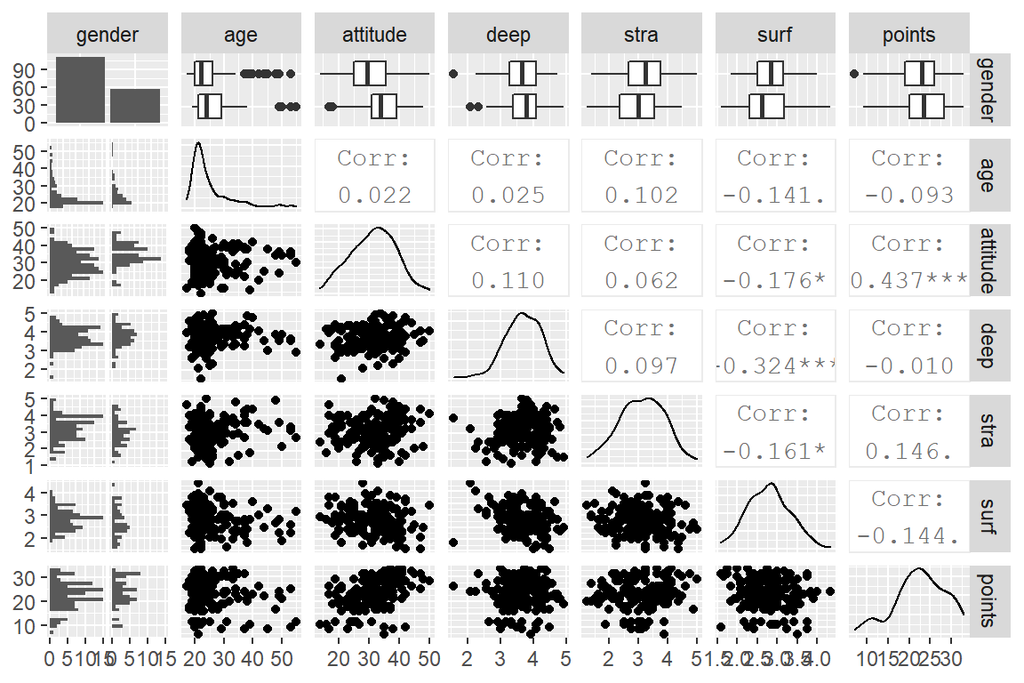

Next, I’ve created a regression model with `points` as the dependent variable and three variables having the highest absolute correlation with `points` as explanatory variables: `attitude`, `stra` and `surf`.

```
##
## Call:
## lm(formula = points ~ attitude + stra + surf, data = learn)
##
## Residuals:
##      Min       1Q   Median       3Q      Max
## -17.1550  -3.4346   0.5156   3.6401  10.8952
##
## Coefficients:
##             Estimate Std. Error t value Pr(>|t|)
## (Intercept) 11.01711    3.68375   2.991  0.00322 **
## attitude     0.33952    0.05741   5.913 1.93e-08 ***
## stra         0.85313    0.54159   1.575  0.11716
## surf        -0.58607    0.80138  -0.731  0.46563
## ---
## Signif. codes:  0 '***' 0.001 '**' 0.01 '*' 0.05 '.' 0.1 ' ' 1
##
## Residual standard error: 5.296 on 162 degrees of freedom
## Multiple R-squared:  0.2074, Adjusted R-squared:  0.1927
## F-statistic: 14.13 on 3 and 162 DF,  p-value: 3.156e-08
```

There’s a statistically significant relationship between`points`and the explanatory variable `attitude` but not between `points` and the other explanatory variables `stra` and `surf`.

The model can be simplified and fitted with `attitude` as the only explanatory variable as follows:

```
##
## Call:
## lm(formula = points ~ attitude, data = learn)
##
## Residuals:
##      Min       1Q   Median       3Q      Max
## -16.9763  -3.2119   0.4339   4.1534  10.6645
##
## Coefficients:
##             Estimate Std. Error t value Pr(>|t|)
## (Intercept) 11.63715    1.83035   6.358 1.95e-09 ***
## attitude     0.35255    0.05674   6.214 4.12e-09 ***
## ---
## Signif. codes:  0 '***' 0.001 '**' 0.01 '*' 0.05 '.' 0.1 ' ' 1
##
## Residual standard error: 5.32 on 164 degrees of freedom
## Multiple R-squared:  0.1906, Adjusted R-squared:  0.1856
## F-statistic: 38.61 on 1 and 164 DF,  p-value: 4.119e-09
```

In addition to a linear relationship between the dependent and independent variables, linear regression model assumes that the residuals are independent, have constant variance, and are normally distributed. Residuals are leftover of the dependent variable after fitting a model (independent variables) to data and they could reveal unexplained patterns in the data by the fitted model. Patterns in residuals can be explored with diagnostic plots.

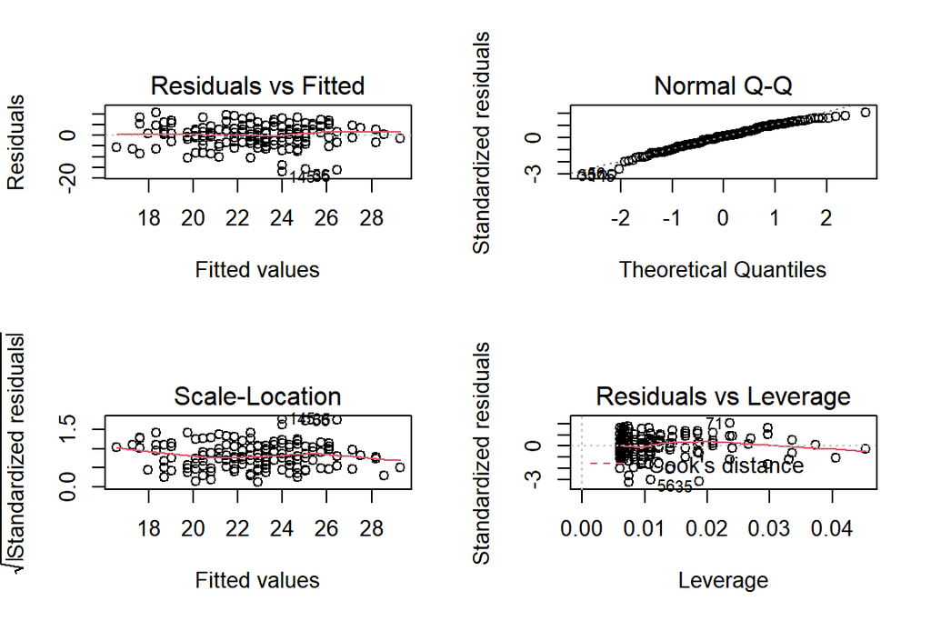

```r
# create a regression model
mymod <- lm(points ~ attitude, data = learn)

# draw diagnostic plots using the plot() function
par(mfrow = c(2,2))
plot(mymod)
```

```r
# Note: intentional deviation from exercise instructions
# To produce plots 1, 2 and 5 only, use argument which = c(1,2,5)
```

**Residuals vs Fitted** plot shows if residuals have non-linear patterns. Here, cases are distributed quite equally around the horizontal line and no obvious pattern can be detected.

**Normal Q-Q** plot helps to assess whether residuals are normally distributed. Here, the points appear to skew away from the straight line especially at the lower tail meaning that residuals are not normally distributed. Cases #145, #35 and #56 should be explored further as they have standardized residuals below -3.

**Scale-Location** plot can be used to check the assumption of constant variance. Here, the residuals appear randomly spread along a horizontal line confirming the assumption.

**Residuals vs Leverage** plot helps to identify influential cases in the data. Here, Cook’s distance lines (red dashed lines) are not even visible, meaning that all cases are well within Cook’s distance and not influential to the regression results.

# 3. Logistic regression

```
## [1] "Fri Dec 04 21:58:32 2020"
```

```r
# access libraries tidyr, dplyr, ggplot2, knitr, broom, ggeffects
library(tidyr); library(dplyr); library(ggplot2); library(knitr); library(broom); library(ggeffects)
```

### 3.1 Overview of data

I’ll use joined student alcohol consumption data from my local folder. I’ve chosen to follow the IODS RStudio Exercise 3 instructions without [the amendments proposed by Reijo Sund](https://mooc.helsinki.fi/mod/forum/discuss.php?d=21096). My script for creating the dataframe is available at https://github.com/ssimovaa/IODS-project/blob/master/data/create_alc.R.

Original data created by [P. Cortez and A. Silva. 2008. Using Data Mining to Predict Secondary School Student Performance](http://www3.dsi.uminho.pt/pcortez/student.pdf) is available in [the UCI Machine Learning Repository](https://archive.ics.uci.edu/ml/datasets/Student+Performance).

```r
# read df alc into memory
alc <- read.csv(file = 'data/alc.csv')
```

Following adjustments were made for `alc`:  
* Student Performance Data (incl. alcohol consumption) from to data sets were joined by matching selected variables  
* variables not used for joining the two data have been combined by averaging (including the grade variables)  
* `alc_use` is the average of `Dalc` and `Walc`  
* `high_use` is `TRUE` if `alc_use` is higher than 2 and `FALSE` otherwise.

```r
# explore df structure
str(alc)
```

```
## 'data.frame':    382 obs. of  35 variables:
##  $ school    : chr  "GP" "GP" "GP" "GP" ...
##  $ sex       : chr  "F" "F" "F" "F" ...
##  $ age       : int  18 17 15 15 16 16 16 17 15 15 ...
##  $ address   : chr  "U" "U" "U" "U" ...
##  $ famsize   : chr  "GT3" "GT3" "LE3" "GT3" ...
##  $ Pstatus   : chr  "A" "T" "T" "T" ...
##  $ Medu      : int  4 1 1 4 3 4 2 4 3 3 ...
##  $ Fedu      : int  4 1 1 2 3 3 2 4 2 4 ...
##  $ Mjob      : chr  "at_home" "at_home" "at_home" "health" ...
##  $ Fjob      : chr  "teacher" "other" "other" "services" ...
##  $ reason    : chr  "course" "course" "other" "home" ...
##  $ nursery   : chr  "yes" "no" "yes" "yes" ...
##  $ internet  : chr  "no" "yes" "yes" "yes" ...
##  $ guardian  : chr  "mother" "father" "mother" "mother" ...
```

[output cut: 21 more lines]

Here’s a more visual overall glimpse at the data. The graphs present the response categories (values) of each variable (key) in the data. The bar height presents the total count of responses in each category.

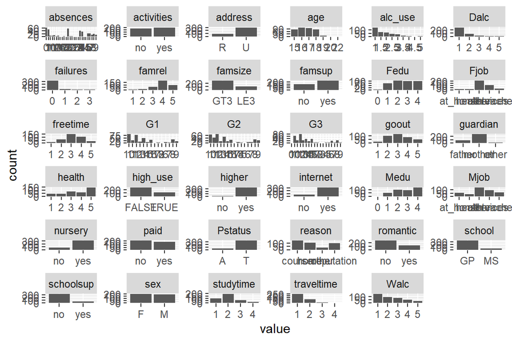

```r
# gather columns into key-value pairs, then draw a bar plot of each variable
gather(alc) %>% ggplot(aes(value)) + facet_wrap("key", scales = "free") + geom_bar()
```

### 3.2 Hypotheses on relationships

I’d expect students with lots of `freetime` after school to consume more alcohol than students on average. On the other hand, `high_use` of alcohol might relate with lower final grades. I’m interested to learn about the differences between the age groups (under/legal age) as well as between the sexes in this context.

#### Alcohol consumption by freetime

Cross tabulating proportion values of `high_use` (FALSE/TRUE) by `freetime` (1 - very low to 5 - very high) confirms my expectation about a positive correlation between the amount of free time and consumption of alcohol.

```r
# cross tab freetime and high_use using proportions
alc %>%
  group_by(freetime, high_use) %>%
  summarise(n = n()) %>%
  mutate(prop = n/sum(n)) %>%      # create proportion variable
  subset(select = c("freetime", "high_use", "prop")) %>%       # drop frequency values
  pivot_wider(names_from = high_use, values_from = prop) %>%     # aggregate for presentation
  kable(format = "html", digits = 2, table.attr = "style='width:40%;'")     # generate table
```

| freetime | FALSE | TRUE |
| --- | --- | --- |
| 1 | 0.88 | 0.12 |
| 2 | 0.75 | 0.25 |
| 3 | 0.74 | 0.26 |
| 4 | 0.63 | 0.37 |
| 5 | 0.58 | 0.42 |

#### Final grade (G3) by high_use and sex

Next, box plots were drawn to compare the range and distribution of final grade `G3` for the level of alcohol use `high_use` and `sex`.

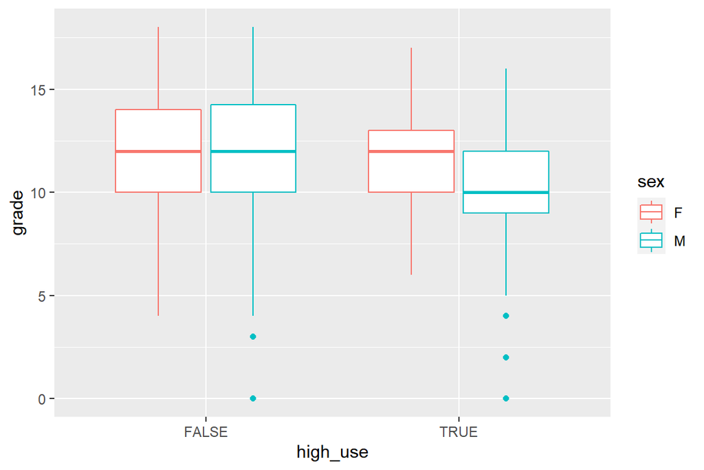

```r
# plot final grade (G3) by high_use and sex
alc %>%
    group_by(sex) %>%
   ggplot(aes(x = high_use, y = G3, col = sex)) %>%
   + geom_boxplot() + ylab("grade")
```

The boxes for male and female students using less alcohol are quite similar in both range and distribution indicating no differences between the groups. Although the box for female students using more alcohol has similar median with the two first groups, it is skewed to left (concentrated towards lower grades), so there might be something to explore further. The median and, in fact, the entire box for male students consuming high levels of alcohol is lower than the other groups suggesting this group is different from the others.

#### Alcohol consumption by age group and sex

To find out if grouping by under/legal age might have a relationship with alcohol consumption, a new column `under_age` (age below 18) was created in the dataframe.

In the crosstab below, `n` presents the row frequencies, i.e. the count of observations grouped by `sex` and `under_age`, while `mean_high_use` indicates the proportion of `high_use`of alcohol within group (on the row).

```r
# Cross tab mean of high_use by under_age and sex
alc %>%
  mutate(under_age = age < 18) %>%    # create new column 'under_age'
  group_by(sex, under_age) %>%
  summarise(mean_high_use = mean(high_use), n = n()) %>%
  kable(format = "html", digits = 2, table.attr = "style='width:40%;'")
```

| sex | under_age | mean_high_use | n |
| --- | --- | --- | --- |
| F | FALSE | 0.15 | 47 |
| F | TRUE | 0.23 | 151 |
| M | FALSE | 0.53 | 47 |
| M | TRUE | 0.34 | 137 |

Cross tabulation of means of `high_use` of alcohol by groups of `sex` and `under_age` indicates that `high_use` of alcohol was more common among male students than females regardless of age. However, the group of male students of legal age stands out with 53% of the group reporting `high_use` of alcohol.

#### Final grades by alcohol consumption and age group

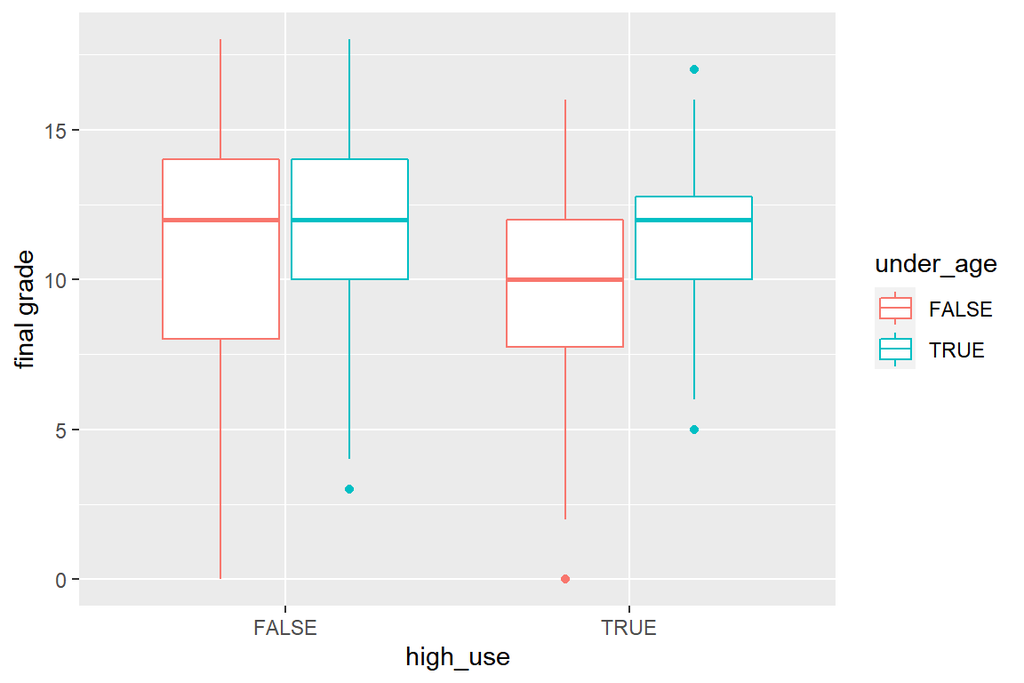

```r
# box plot high_use and final grade (G3) by subsets of age
alc %>%
  mutate(under_age = age < 18) %>%     # create new column 'under_age'
  group_by(under_age) %>%
  ggplot(aes(x = high_use, y = G3, col = under_age)) %>%
  + geom_boxplot() + ylab("final grade")
```

### 3.3 Model fitting with multiple predictor variables

By specifying a binomial error distribution with the function `glm()` I can fit a logistic regression model to predict the probability of a student’s `high_use` of alcohol (a binary outcome) with variables `freetime` (numeric), `sex` (binary), `under_age` (binary) and `G3` (numeric).

Note1: female `sexF` and `under_ageFALSE` are set as the reference group for the predictor factors.

Note2: as an afterthought, `freetime`is actually an ordered categorical variable but I’ve opted to treat it as continuous (with linear effects) here.

```r
# define a new column
alc_age <- mutate(alc, under_age = age < 18)

# fit a model with glm()
m1 <- glm(high_use ~ freetime + sex + under_age + G3, data = alc_age, family = "binomial")

# print out a summary of the model
summary(m1)
```

```
##
## Call:
## glm(formula = high_use ~ freetime + sex + under_age + G3, family = "binomial",
##     data = alc_age)
##
## Deviance Residuals:
##     Min       1Q   Median       3Q      Max
## -1.4085  -0.8563  -0.6645   1.2037   2.1104
##
## Coefficients:
##               Estimate Std. Error z value Pr(>|z|)
## (Intercept)   -1.08898    0.58247  -1.870  0.06154 .
## freetime       0.26527    0.12262   2.163  0.03052 *
## sexM           0.77881    0.23785   3.274  0.00106 **
## under_ageTRUE -0.17279    0.26788  -0.645  0.51891
## G3            -0.08127    0.03543  -2.293  0.02182 *
## ---
## Signif. codes:  0 '***' 0.001 '**' 0.01 '*' 0.05 '.' 0.1 ' ' 1
##
## (Dispersion parameter for binomial family taken to be 1)
##
##     Null deviance: 465.68  on 381  degrees of freedom
## Residual deviance: 439.48  on 377  degrees of freedom
## AIC: 449.48
##
## Number of Fisher Scoring iterations: 4
```

Each estimated coefficient in the summary above is the expected change in the log odds of `high_use` for a unit increase in the corresponding predictor variable holding the other predictor variables constant at certain value.

From the estimates of the coefficients, I can see that `freetime` and male gender `sexM` influence `high_use` positively while final grades `G3` and age group `under_ageTRUE` have a negative effect. The coefficient of `under_ageTRUE` is not significant (p > 0.05), while the coefficients of `freetime`, `sexM` and `G3` are significant.

Deviance is a measure for goodness of fit in glm. Null deviance is the goodness for a model fitted with only the intercept. Adding the four independent variables to the model decreased the (residual) deviance by 26.2 points with loss of 4 degrees of freedom. Lower score means a better fit.

Akaike information criteria AIC is a measure for the quality of the model based on deviance (but it also penalizes more complicated models). It can only be interpreted when comparing models (lower is better), otherwise the number has no meaning.

Fisher scoring tells that the algorithm needed 4 iterations to perform the fit, indicating only that the model did converge and not telling anything more about the model or the goodness of its fit.

Now, if I refit the model by removing the least influential variable `under_age`, I can use the residual deviance and AIC scores to compare the models.

```r
# refit the model with glm()
m2 <- glm(high_use ~ freetime + sex + G3, data = alc, family = "binomial")

# print out a summary of the model
summary(m2)
```

```
##
## Call:
## glm(formula = high_use ~ freetime + sex + G3, family = "binomial",
##     data = alc)
##
## Deviance Residuals:
##     Min       1Q   Median       3Q      Max
## -1.3580  -0.8621  -0.6638   1.2485   2.0999
##
## Coefficients:
##             Estimate Std. Error z value Pr(>|z|)
## (Intercept) -1.15930    0.57227  -2.026   0.0428 *
## freetime     0.26085    0.12227   2.133   0.0329 *
## sexM         0.78214    0.23775   3.290   0.0010 **
## G3          -0.08531    0.03493  -2.442   0.0146 *
## ---
## Signif. codes:  0 '***' 0.001 '**' 0.01 '*' 0.05 '.' 0.1 ' ' 1
##
## (Dispersion parameter for binomial family taken to be 1)
##
##     Null deviance: 465.68  on 381  degrees of freedom
## Residual deviance: 439.89  on 378  degrees of freedom
## AIC: 447.89
##
## Number of Fisher Scoring iterations: 4
```

Removing the variable doesn’t improve residual deviance but the refitted model gets a lower (better) AIC scores. I think it’s fair to conclude at this point that whether students were under or of the legal age (18) does not significantly affect the odds of being in the `high_use` group and I can reject my hypothesis regarding this relationship.

In logistic regression, the outcome variable by itself does not have a linear relationship with the predictor variables but its logit transformation does.

Odds ratios are simply the exponentiated coefficients from the logit model. The 95% confidence interval around the odds ratios are the exponentiated 95% confidence intervals from the logit model. Using `tidy()` function from `broom` package I can produce a table with the results in terms of odds ratios including their confidence interval.

```r
m2 %>%
  tidy(exponentiate = T, conf.int = T) %>%
  mutate_if(is.numeric, ~ round(.,2)) %>%
  kable(align = c("l", rep("c", 6)))
```

| term | estimate | std.error | statistic | p.value | conf.low | conf.high |
| --- | --- | --- | --- | --- | --- | --- |
| (Intercept) | 0.31 | 0.57 | -2.03 | 0.04 | 0.10 | 0.95 |
| freetime | 1.30 | 0.12 | 2.13 | 0.03 | 1.02 | 1.66 |
| sexM | 2.19 | 0.24 | 3.29 | 0.00 | 1.38 | 3.50 |
| G3 | 0.92 | 0.03 | -2.44 | 0.01 | 0.86 | 0.98 |

So, my fitted model says that, holding `freetime` and grades `G3` at a fixed value, the odds ratio of being the group `high_use` of alcohol for male `sexM` students is 2.19, i.e. the odds for male students are 119% higher than for female students. Holding `sex` and grades `G3` at a fixed value, a one-unit increase in `freetime` increases the odds of being in the `high_use` group by 30%. And holding `sex` and `freetime` at a fixed value, a one-unit increase in final grades `G3` decreases the odds of being in the high_use` group by 8%.

It looks like my hypothesis that more `freetime` increases the odds of `high_use` of alcohol is confirmed, as is the hypothesis regarding a negative relationship between final grades `G3` and `high_use`.

### 3.4 Predictions

The model goodness of fit can also be evaluated based on the difference between the observed and predicted data. I’ve crosstabulated the observed values for `high_use` against the values predicted by my model. The crosstab shows how many observations of `high_use` my model predicts correctly (FALSE/FALSE and TRUE/TRUE) as well as those it predicts incorrectly.

```r
# predict() the probability of high_use
probabilities <- predict(m2, type = "response")

# add the predicted probabilities to 'alc'
alc <- mutate(alc, probability = probabilities)

# use the probabilities to make a prediction of high_use
alc <- mutate(alc, prediction = probability > 0.5)

# tabulate the target variable versus the predictions
table(high_use = alc$high_use, prediction = alc$prediction)
```

```
##         prediction
## high_use FALSE TRUE
##    FALSE   259    9
##    TRUE    100   14
```

The model accuracy can be calculated as the percentage of values predicted correctly. The accuracy of my model is 71.5%.

```r
(259+14)/382
```

```
## [1] 0.7146597
```

```r
m0 <- glm(high_use ~1, data = alc, family = "binomial")

# predict() the probability of high_use
probabilities <- predict(m0, type = "response")

# add the predicted probabilities to 'alc'
alc <- mutate(alc, probability = probabilities)

# use the probabilities to make a prediction of high_use
alc <- mutate(alc, prediction = probability > 0.5)

# tabulate the target variable versus the predictions
table(high_use = alc$high_use, prediction = alc$prediction)
```

```
##         prediction
## high_use FALSE
##    FALSE   268
##    TRUE    114
```

The predicted probabilities of `high_use` can be plotted via marginal effects with `ggpredict()`function from `ggeffects` package. The tables below visualize the probability of `high_use` separately for female and male students as predicted by the final grade `G3` at different levels of `freetime`. The shaded areas present 95% CI.

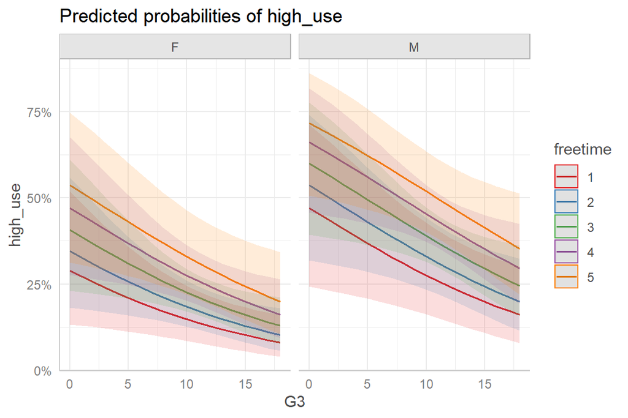

```r
# coerce high_use as numeric factor
alc$high_use = as.numeric(alc$high_use)
# refit model numeric high_use
m5 <- glm(high_use ~ freetime + sex + G3, data = alc, family = "binomial")
# plot predicted probabilities
plot(ggpredict(m5, c("G3", "freetime", "sex")))
```

### 3.5 Cross validation

```r
# define a loss function (average prediction error)
loss_func <- function(class, prob) {
  n_wrong <- abs(class - prob) > 0.5
  mean(n_wrong)
}

# compute the average number of wrong predictions in the (training) data
loss_func(class = alc$high_use, prob = alc$probability)
```

```
## [1] 0.2984293
```

```r
# K-fold cross-validation
library(boot)
cv <- cv.glm(data = alc, cost = loss_func, glmfit = m2, K = 10)

# average number of wrong predictions in the cross validation
cv$delta[1]
```

```
## [1] 0.3036649
```

# 4. Clustering and classification

```
## [1] "Fri Dec 04 21:58:41 2020"
```

### 4.1 Boston MASS data exploration

```r
# access libraries
library(MASS); library(factoextra); library(corrplot); library(tidyr); library(dplyr); library(ggplot2); library(GGally); library(summarytools); library(knitr)
```

```r
# load data
data(Boston)
```

The Boston dataset from the MASS R package contains information regarding different areas in the city of Boston. This dataset with 506 cases (rows) contains information collected by the U.S Census Service concerning housing in the area of Boston Mass. The data was originally published by Harrison, D. and Rubinfeld, D.L. 1978. Hedonic prices and the demand for clean air. J. Environ. Economics & Management (5), 81-102.

There are 14 variables (columns) in the dataset. The variables are:  
- `crim`: per capita crime rate by town  
- `zn`: proportion of residential land zoned for lots over 25,000 sq.ft  
- `indus`: proportion of non-retail business acres per town  
- `chas`: Charles River dummy variable (= 1 if tract bounds river; 0 otherwise)  
- `nox`: nitrogen oxides concentration (parts per 10 million)  
- `rm`: average number of rooms per dwelling  
- `age`: proportion of owner-occupied units built prior to 1940  
- `dis`: weighted mean of distances to five Boston employment centers  
- `rad`: index of accessibility to radial highways  
- `tax`: full-value property-tax rate per $10,000  
- `ptratio`: pupil-teacher ratio by town  
- `black`: 1000(Bk - 0.63)^2 where Bk is the proportion of blacks by town  
- `lstat`: lower status of the population (percent)  
- `medv`: median value of owner-occupied homes in $1000s

To show summaries of the variables, I wanted to try `dfSummary()` function from `summarytools` package. It provides this really neat html output with basic descriptive statistics (or values for categorical variables) and simple histograms or bar plots according to data type. IQR = interquartile range, CV = coefficient of variance. There are no missing cases nor dublicates, and the variables are numeric except `chas` and `rad` which are integers.

```r
# summary statistics
print(dfSummary(Boston), method = "render", plain.ascii = FALSE, style = "grid", varnumbers = FALSE, valid.col = FALSE)
```

Data Frame Summary

**Dimensions**: 506 x 14  
**Duplicates**: 0

| **Variable** | **Stats / Values** | **Freqs (% of Valid)** | **Graph** | **Missing** |
| --- | --- | --- | --- | --- |
| crim [numeric] | Mean (sd) : 3.6 (8.6) min < med < max: 0 < 0.3 < 89 IQR (CV) : 3.6 (2.4) | 504 distinct values |  | 0 (0%) |
| zn [numeric] | Mean (sd) : 11.4 (23.3) min < med < max: 0 < 0 < 100 IQR (CV) : 12.5 (2.1) | 26 distinct values |  | 0 (0%) |
| indus [numeric] | Mean (sd) : 11.1 (6.9) min < med < max: 0.5 < 9.7 < 27.7 IQR (CV) : 12.9 (0.6) | 76 distinct values |  | 0 (0%) |
| chas [integer] | Min : 0 Mean : 0.1 Max : 1 | 0 : 471 ( 93.1% ) 1 : 35 ( 6.9% ) |  | 0 (0%) |
| nox [numeric] | Mean (sd) : 0.6 (0.1) min < med < max: 0.4 < 0.5 < 0.9 IQR (CV) : 0.2 (0.2) | 81 distinct values |  | 0 (0%) |
| rm [numeric] | Mean (sd) : 6.3 (0.7) min < med < max: 3.6 < 6.2 < 8.8 IQR (CV) : 0.7 (0.1) | 446 distinct values |  | 0 (0%) |
| age [numeric] | Mean (sd) : 68.6 (28.1) min < med < max: 2.9 < 77.5 < 100 IQR (CV) : 49 (0.4) | 356 distinct values |  | 0 (0%) |
| dis [numeric] | Mean (sd) : 3.8 (2.1) min < med < max: 1.1 < 3.2 < 12.1 IQR (CV) : 3.1 (0.6) | 412 distinct values |  | 0 (0%) |
| rad [integer] | Mean (sd) : 9.5 (8.7) min < med < max: 1 < 5 < 24 IQR (CV) : 20 (0.9) | 1 : 20 ( 4.0% ) 2 : 24 ( 4.7% ) 3 : 38 ( 7.5% ) 4 : 110 ( 21.7% ) 5 : 115 ( 22.7% ) 6 : 26 ( 5.1% ) 7 : 17 ( 3.4% ) 8 : 24 ( 4.7% ) 24 : 132 ( 26.1% ) |  | 0 (0%) |
| tax [numeric] | Mean (sd) : 408.2 (168.5) min < med < max: 187 < 330 < 711 IQR (CV) : 387 (0.4) | 66 distinct values |  | 0 (0%) |
| ptratio [numeric] | Mean (sd) : 18.5 (2.2) min < med < max: 12.6 < 19 < 22 IQR (CV) : 2.8 (0.1) | 46 distinct values |  | 0 (0%) |
| black [numeric] | Mean (sd) : 356.7 (91.3) min < med < max: 0.3 < 391.4 < 396.9 IQR (CV) : 20.8 (0.3) | 357 distinct values |  | 0 (0%) |
| lstat [numeric] | Mean (sd) : 12.7 (7.1) min < med < max: 1.7 < 11.4 < 38 IQR (CV) : 10 (0.6) | 455 distinct values |  | 0 (0%) |
| medv [numeric] | Mean (sd) : 22.5 (9.2) min < med < max: 5 < 21.2 < 50 IQR (CV) : 8 (0.4) | 229 distinct values |  | 0 (0%) |

Generated by summarytools 0.9.6 ([R](https://www.r-project.org/) version 4.0.3)  
2020-12-04

The summary statistics and histograms show that e.g.  
- `crim`, `zn` are heavily skewed to the right, also `dis` is right-skewed but not as heavily  
- if `chas` is to be treated as numeric data, then it too is right-skewed  
- `black`is heavily skewed to the left, as is `age`  
- `rm` is pretty normally distributed  
- `indus`, `tax`, and perhaps `rad` too, have bimodal distributions

To highlight which variables are most correlated, I plotted this correlation matrix with `corrplot` package. Positive correlations are displayed in blue and negative correlations in red color. Color intensity and the size of the circle are proportional to the correlation coefficients.

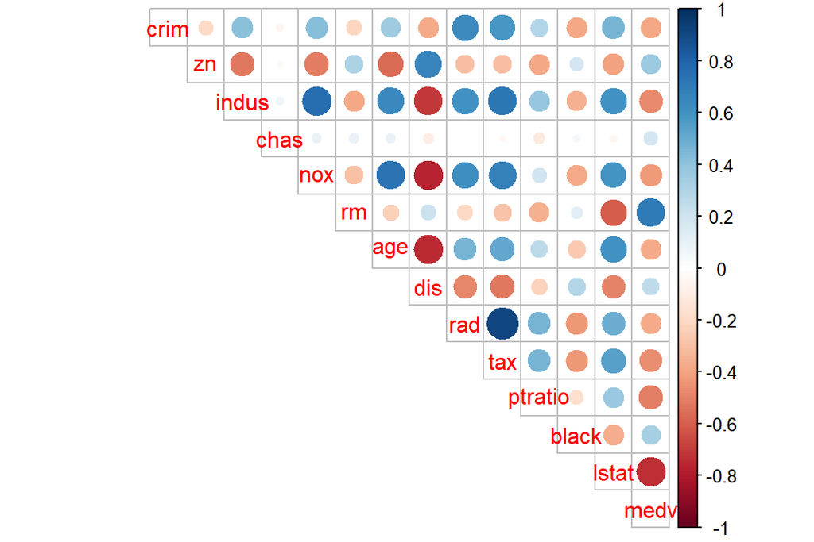

```r
# correlation matrix
corr_matrix<-cor(Boston) %>% round(digits = 2)
# visualization
corrplot(corr_matrix, type = "upper", tl.pos="d")
```

From the visualizations above, I can conclude e.g. regarding variable `crim` that  
- it is heavily skewed to the right  
- it has no linear relationship with `chas` but  
- it is (at least weakly) related to all other variables in the dataset and  
- its strongest correlations with `rad` and `tax` are positive.

### 4.2 Data transformation

#### Standardization

When performing multivariate analysis on variables that don’t share the units, or have very different variations, it’s good to standardize the data first. I’ll use the `scale()` function which, by default, centers and scales all numeric variables in the dataset. (The function also changes the dataset into a matrix, so I’ve changed it back to a dataframe.)

```r
# standardization
boston_scaled <- scale(Boston)
# coerce as dataframe
boston_scaled <- as.data.frame(boston_scaled)
```

Now the standardized distributions have means of 0 and standard deviations of 1, as shown in the summary below. Evidently, `scale` function also treats integers as numeric variables and I’m not exactly sure it makes sense with the binary dummy variable `chas`.

It’s also evident comparing the histograms before and after scaling that standardization changes the data ranges, not the distributions. The CV values in the summary for `boston_scaled` are confusing; I’m actually surprised to see numeric values for CV at all (CV = sd / mean = 1/0, so the statistic should return NaN or some error code, I think).

```r
# print summary statistics
print(dfSummary(boston_scaled), method = "render", plain.ascii = FALSE, style = "grid", varnumbers = FALSE, valid.col = FALSE, max.tbl.height = 300)
```

Data Frame Summary

**Dimensions**: 506 x 14  
**Duplicates**: 0

| **Variable** | **Stats / Values** | **Freqs (% of Valid)** | **Graph** | **Missing** |
| --- | --- | --- | --- | --- |
| crim [numeric] | Mean (sd) : 0 (1) min < med < max: -0.4 < -0.4 < 9.9 IQR (CV) : 0.4 (-138831414651986864) | 504 distinct values |  | 0 (0%) |
| zn [numeric] | Mean (sd) : 0 (1) min < med < max: -0.5 < -0.5 < 3.8 IQR (CV) : 0.5 (43811969609182128) | 26 distinct values |  | 0 (0%) |
| indus [numeric] | Mean (sd) : 0 (1) min < med < max: -1.6 < -0.2 < 2.4 IQR (CV) : 1.9 (62684298633847472) | 76 distinct values |  | 0 (0%) |
| chas [numeric] | Min : -0.3 Mean : 0 Max : 3.7 | -0.27! : 471 ( 93.1% ) 3.66! : 35 ( 6.9% ) ! rounded |  | 0 (0%) |
| nox [numeric] | Mean (sd) : 0 (1) min < med < max: -1.5 < -0.1 < 2.7 IQR (CV) : 1.5 (-4651114786962318) | 81 distinct values |  | 0 (0%) |
| rm [numeric] | Mean (sd) : 0 (1) min < med < max: -3.9 < -0.1 < 3.6 IQR (CV) : 1.1 (-9465552692071638) | 446 distinct values |  | 0 (0%) |
| age [numeric] | Mean (sd) : 0 (1) min < med < max: -2.3 < 0.3 < 1.1 IQR (CV) : 1.7 (-6085103283712292) | 356 distinct values |  | 0 (0%) |
| dis [numeric] | Mean (sd) : 0 (1) min < med < max: -1.3 < -0.3 < 4 IQR (CV) : 1.5 (8672432616949923) | 412 distinct values |  | 0 (0%) |
| rad [numeric] | Mean (sd) : 0 (1) min < med < max: -1 < -0.5 < 1.7 IQR (CV) : 2.3 (20834845606262996) | -0.98! : 20 ( 4.0% ) -0.87! : 24 ( 4.7% ) -0.75! : 38 ( 7.5% ) -0.64! : 110 ( 21.7% ) -0.52! : 115 ( 22.7% ) -0.41! : 26 ( 5.1% ) -0.29! : 17 ( 3.4% ) -0.18! : 24 ( 4.7% ) 1.66! : 132 ( 26.1% ) ! roun… |  | 0 (0%) |
| tax [numeric] | Mean (sd) : 0 (1) min < med < max: -1.3 < -0.5 < 1.8 IQR (CV) : 2.3 (49396975557245088) | 66 distinct values |  | 0 (0%) |
| ptratio [numeric] | Mean (sd) : 0 (1) min < med < max: -2.7 < 0.3 < 1.6 IQR (CV) : 1.3 (-2548260100514846) | 46 distinct values |  | 0 (0%) |
| black [numeric] | Mean (sd) : 0 (1) min < med < max: -3.9 < 0.4 < 0.4 IQR (CV) : 0.2 (-8682976848282282) | 357 distinct values |  | 0 (0%) |
| lstat [numeric] | Mean (sd) : 0 (1) min < med < max: -1.5 < -0.2 < 3.5 IQR (CV) : 1.4 (-14178810137013006) | 455 distinct values |  | 0 (0%) |
| medv [numeric] | Mean (sd) : 0 (1) min < med < max: -1.9 < -0.1 < 3 IQR (CV) : 0.9 (-7274678355106612) | 229 distinct values |  | 0 (0%) |

Generated by summarytools 0.9.6 ([R](https://www.r-project.org/) version 4.0.3)  
2020-12-04

#### Transforming the continuous variable `crim` to categorical `crime`

```r
# print summary of the scaled crime rate
summary(boston_scaled$crim)
```

```
##      Min.   1st Qu.    Median      Mean   3rd Qu.      Max.
## -0.419367 -0.410563 -0.390280  0.000000  0.007389  9.924110
```

```r
# create a quantile vector of 'crim'
bins <- quantile(boston_scaled$crim)
bins
```

```
##           0%          25%          50%          75%         100%
## -0.419366929 -0.410563278 -0.390280295  0.007389247  9.924109610
```

```r
# create a categorical variable 'crime'
crime <- cut(boston_scaled$crim, breaks = bins, include.lowest = TRUE, labels = c("low", "med_low", "med_high", "high"))
table(crime)
```

```
## crime
##      low  med_low med_high     high
##      127      126      126      127
```

```r
# remove original 'crim' from the dataset
bn_scaled <- dplyr::select(boston_scaled, -crim)
# add the new categorical 'crime' to scaled data
bn_scal1 <- data.frame(bn_scaled, crime)
str(bn_scal1)
```

```
## 'data.frame':    506 obs. of  14 variables:
##  $ zn     : num  0.285 -0.487 -0.487 -0.487 -0.487 ...
##  $ indus  : num  -1.287 -0.593 -0.593 -1.306 -1.306 ...
##  $ chas   : num  -0.272 -0.272 -0.272 -0.272 -0.272 ...
##  $ nox    : num  -0.144 -0.74 -0.74 -0.834 -0.834 ...
##  $ rm     : num  0.413 0.194 1.281 1.015 1.227 ...
##  $ age    : num  -0.12 0.367 -0.266 -0.809 -0.511 ...
##  $ dis    : num  0.14 0.557 0.557 1.077 1.077 ...
##  $ rad    : num  -0.982 -0.867 -0.867 -0.752 -0.752 ...
##  $ tax    : num  -0.666 -0.986 -0.986 -1.105 -1.105 ...
##  $ ptratio: num  -1.458 -0.303 -0.303 0.113 0.113 ...
##  $ black  : num  0.441 0.441 0.396 0.416 0.441 ...
##  $ lstat  : num  -1.074 -0.492 -1.208 -1.36 -1.025 ...
##  $ medv   : num  0.16 -0.101 1.323 1.182 1.486 ...
##  $ crime  : Factor w/ 4 levels "low","med_low",..: 1 1 1 1 1 1 2 2 2 2 ...
```

#### Split data into train and test sets

The standardized and transformed data is split into train (80%) and test (20%) sets.

```r
# number of rows in the Boston dataset
n <- nrow(bn_scal1)
# choose randomly 80% of the rows
ind <- sample(n,  size = n * 0.8)
# create train set
train <- bn_scal1[ind,]
dim(train)
```

```
## [1] 404  14
```

The train set now consists of 404 rows and 14 columns including the `crime` variable.

```r
# create test set
test <- bn_scal1[-ind,]
# save the correct classes from test data
correct_classes <- test$crime
# remove the crime variable from test data
test <- dplyr::select(test, -crime)
dim(test)
```

```
## [1] 102  13
```

And the test set has 102 rows and 13 columns after the `crime` variable was removed.

### 4.3 Linear discriminant analysis

Linear discriminant analysis (LDA) is a classification method for predicting categories.

```r
# linear discriminant analysis
lda.fit <- lda(crime ~ ., data = train)
# print the lda.fit object
lda.fit
```

```
## Call:
## lda(crime ~ ., data = train)
##
## Prior probabilities of groups:
##       low   med_low  med_high      high
## 0.2524752 0.2524752 0.2326733 0.2623762
##
## Group means:
##                   zn      indus         chas        nox          rm        age
## low       0.90563620 -0.9007732 -0.117932980 -0.8742397  0.42970007 -0.8898907
## med_low  -0.09798305 -0.2320543 -0.002135914 -0.5491758 -0.14300466 -0.3071346
## med_high -0.40331047  0.1460951  0.188395428  0.3289111 -0.03522745  0.3400838
## high     -0.48724019  1.0170298 -0.049474337  1.0854260 -0.38928908  0.8441846
##                 dis        rad        tax     ptratio      black       lstat
## low       0.8333700 -0.6902506 -0.7244107 -0.42959206  0.3838337 -0.76713543
## med_low   0.3337021 -0.5438774 -0.4408868 -0.10761683  0.3397651 -0.10406874
## med_high -0.3035288 -0.4100812 -0.3019912 -0.06643653  0.1040178  0.07477292
## high     -0.8534988  1.6390172  1.5146914  0.78181164 -0.7547199  0.88033962
##                 medv
## low       0.49861577
## med_low  -0.01156187
## med_high  0.02974596
## high     -0.72703101
##
## Coefficients of linear discriminants:
##                 LD1          LD2         LD3
## zn       0.09626577  0.796999634 -0.82307725
## indus   -0.02519706 -0.301210010  0.55824004
## chas    -0.10017314 -0.114721881  0.11048538
## nox      0.48171279 -0.649031384 -1.64472294
## rm      -0.05101286 -0.024103989 -0.17478289
## age      0.23009970 -0.298210727 -0.03000647
## dis     -0.04682536 -0.409367548  0.24808969
## rad      3.18167027  0.940142835  0.15102568
## tax     -0.02657998 -0.017538985  0.58687820
## ptratio  0.18552193 -0.064530754 -0.53847536
## black   -0.12141852 -0.009116706  0.12290219
## lstat    0.25171223 -0.313500315  0.27345035
## medv     0.23175251 -0.413961528 -0.26235548
##
## Proportion of trace:
##    LD1    LD2    LD3
## 0.9561 0.0318 0.0120
```

*Prior probabilities of groups* reflect the proportion of each group in the training dataset. *Group means* are the average values of each of the variables for each group. *Coefficients of linear discriminants* provide the linear combination of variables that are used to form the LDA decision rule. Because there are 4 groups, there are 4–1 linear discriminants (LD). For each LD, there is one coefficient corresponding to each of the variables. *Proportion of the trace* gives the variance explained by each LD function. Here, LD1 explains 96% of the variance, with the remainder explained by LD2 and LD3.

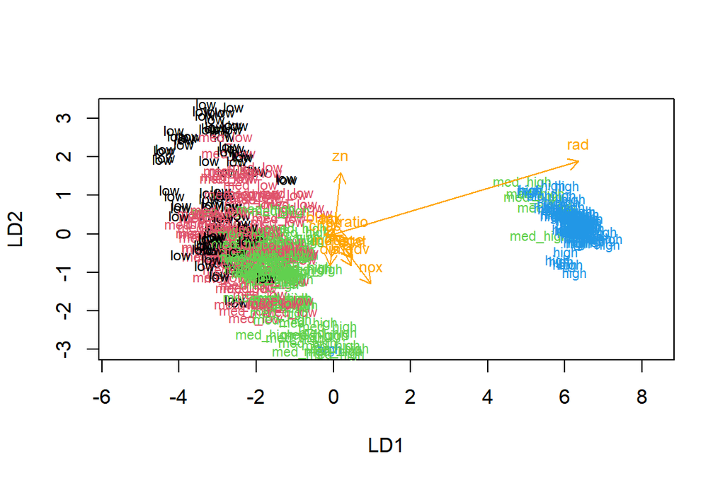

```r
# the function for lda biplot arrows
lda.arrows <- function(x, myscale = 1, arrow_heads = 0.1, color = "orange", tex = 0.75, choices = c(1,2)){
  heads <- coef(x)
  arrows(x0 = 0, y0 = 0,
         x1 = myscale * heads[,choices[1]],
         y1 = myscale * heads[,choices[2]], col=color, length = arrow_heads)
  text(myscale * heads[,choices], labels = row.names(heads),
       cex = tex, col=color, pos=3)
}
# target classes as numeric
classes <- as.numeric(train$crime)
# plot the lda results
plot(lda.fit, dimen = 2, col = classes, pch = classes)
lda.arrows(lda.fit, myscale = 2)
```

```r
# predict classes with test data
lda.pred <- predict(lda.fit, newdata = test)
# cross tabulate the results
acc <- table(correct = correct_classes, predicted = lda.pred$class)
acc
```

```
##           predicted
## correct    low med_low med_high high
##   low       17       7        1    0
##   med_low    4      14        6    0
##   med_high   1       4       26    1
##   high       0       0        0   21
```

```r
sum(acc[row(acc) == col(acc)]) / sum(acc)
```

```
## [1] 0.7647059
```

### 4.4 K-means clustering

K-means clustering is an unsupervised machine learning algorithm. It looks for patterns in an unlabeled dataset with minimum human supervision and tries to group similar kinds of items to form clusters. The algorithm aims to maximize the intra-class similarity and minimize the inter-class similarity. The k represents the number of clusters predefined by the analyst.

#### Data preparation

```r
# reload data
data(Boston)
# standardize data
bn_scal2 <- scale(Boston)
# coerce as dataframe
bn_scal2 <- as.data.frame(bn_scal2)
```

#### Understand distance metrics

Euclidean distance is the shortest distance between two points. The k-means algorithm uses this metric to measure the distance (similarity or dissimilarity) between data points.

```r
# euclidean distance matrix
dist_eu <- dist(bn_scal2)
# look at the summary of the distances
summary(dist_eu)
```

```
##    Min. 1st Qu.  Median    Mean 3rd Qu.    Max.
##  0.1343  3.4625  4.8241  4.9111  6.1863 14.3970
```

Manhattan distance is also known as the *city block distance*. It’s the sum of absolute differences between points across all the dimensions.

```r
# manhattan distance matrix
dist_man <- dist(bn_scal2, method = 'manhattan')
# look at the summary of the distances
summary(dist_man)
```

```
##    Min. 1st Qu.  Median    Mean 3rd Qu.    Max.
##  0.2662  8.4832 12.6090 13.5488 17.7568 48.8618
```

#### K-means algorithm

K-means can be computed with the `kmeans()` function. The number of clusters (k) is set with the argument `centers`, and the option `nstart` attempts multiple initial configurations and reports on the best one. But before running the algorithm, the optimal number k must be determined.

In order to find the optimal number of clusters, the Elbow method is used here. The method looks at the total within-cluster sum of square (WSS) as a function of the number of clusters. I’m using the `factoextra`::`fviz_nbclust()` function which has the Elbow method nicely wrapped up as a single function.

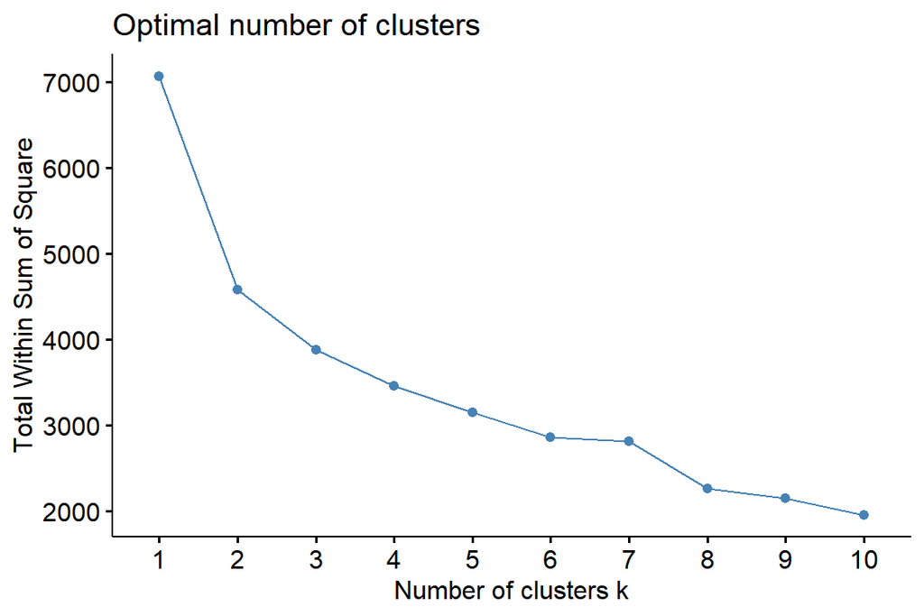

```r
# set seed to get a reproducible random result
set.seed(123)
# Elbow method
fviz_nbclust(bn_scal2, kmeans, method = "wss")
```

The optimal number of clusters appears at the bend in the elbow. Here the Elbow method is a bit ambiguous: is the bend at k = 2 or higher? Just to check I’ll use another method called Silhouette which is also easily available via the `fviz_nbclust()` function.

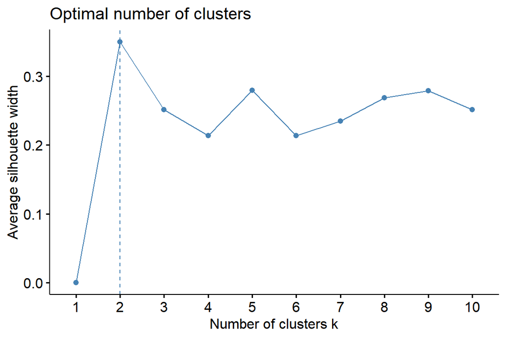

```r
# set seed to get a reproducible random result
set.seed(123)
# Sihouette method
fviz_nbclust(bn_scal2, kmeans, method = "silhouette")
```

Based on the Silhouette method, the optimal number of clusters k = 2, which I’ll enter as `centers = 2` argument to run the k-means algorithm. I’ll use the `fviz_cluster()` function to plot the clusters. This function performs principal component analysis to represent the variables in a two-dimensional plane.

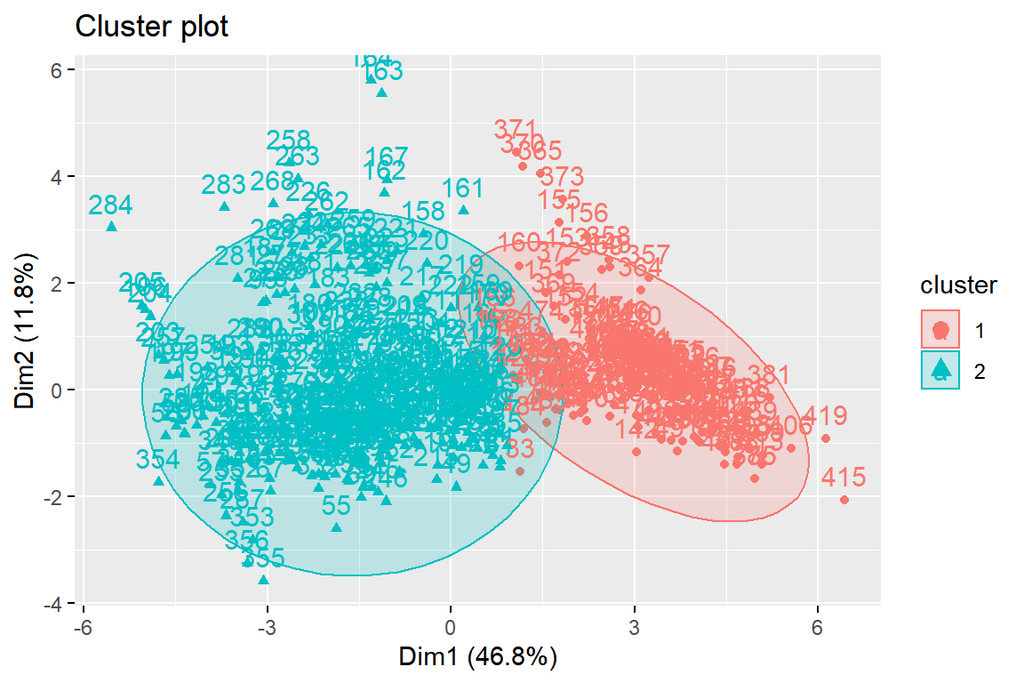

```r
# set seed to get a reproducible random result
set.seed(123)
# run k-means algorithm
k2 <- kmeans(bn_scal2, centers = 2, nstart = 25)
# visualize using PCA
fviz_cluster(k2, bn_scal2, ellipse.type = "norm")
```

# 5. Dimension reduction techniques

```
## [1] "Fri Dec 04 21:58:48 2020"
```

```r
# access libraries
library(tidyr); library(dplyr); library(PerformanceAnalytics); library(pastecs); library(FactoMineR); library(knitr); library(FactoMineR); library(factoextra); library(ggplot2)
```

### 5.1 ‘Human’ data

The `human` dataset originates from the United Nations Development Programme. Original data and technical details are available at http://hdr.undp.org/en/content/human-development-index-hdi.

The column separator in the data file is a comma. The first row includes the column names.

```r
# read df human into memory
human <- read.csv(file = 'data/new_human.csv', row.names = 1)
```

Having the dataset loaded to R, I’ll start with exploratory data analysis.

```r
# print structure of the dataset
str(human)
```

```
## 'data.frame':    155 obs. of  8 variables:
##  $ GNIpc : int  64992 42261 56431 44025 45435 43919 39568 52947 42155 32689 ...
##  $ LE    : num  81.6 82.4 83 80.2 81.6 80.9 80.9 79.1 82 81.8 ...
##  $ EDS   : num  17.5 20.2 15.8 18.7 17.9 16.5 18.6 16.5 15.9 19.2 ...
##  $ MMR   : int  4 6 6 5 6 7 9 28 11 8 ...
##  $ ABR   : num  7.8 12.1 1.9 5.1 6.2 3.8 8.2 31 14.5 25.3 ...
##  $ PR    : num  39.6 30.5 28.5 38 36.9 36.9 19.9 19.4 28.2 31.4 ...
##  $ SE_f  : num  97.4 94.3 95 95.5 87.7 96.3 80.5 95.1 100 95 ...
##  $ LFPR_f: num  61.2 58.8 61.8 58.7 58.5 53.6 53.1 56.3 61.6 62 ...
```

```r
# print out the first 6 rows
head(human)
```

```
##             GNIpc   LE  EDS MMR  ABR   PR SE_f LFPR_f
## Norway      64992 81.6 17.5   4  7.8 39.6 97.4   61.2
## Australia   42261 82.4 20.2   6 12.1 30.5 94.3   58.8
## Switzerland 56431 83.0 15.8   6  1.9 28.5 95.0   61.8
## Denmark     44025 80.2 18.7   5  5.1 38.0 95.5   58.7
## Netherlands 45435 81.6 17.9   6  6.2 36.9 87.7   58.5
## Germany     43919 80.9 16.5   7  3.8 36.9 96.3   53.6
```

The dataset `human` is a dataframe containing data from 155 countries (rows) on 8 variables (columns). All variables are numeric or integers. The variables measure the dimension of gender inequality and human development as defined by the United Nations Development Programme. Variables included in this dataset are:  
- `GNIpc` Gross National Income per capita ($)  
- `LE` Life expectancy at birth (years)  
- `EDS` Expected years of schooling (years)  
- `MMR` Maternal mortality ratio (deaths per 100,000 live births)  
- `ABR` Adolescent birth rate (births per 1,000 women ages 15–19)  
- `PR` Percentage of female representatives in parliament (% of seats held by women)  
- `SE_f` Proportion of females with at least secondary education (%)  
- `LFPR_f` Proportion of females in the labor force (%).

```r
# Compute descriptive statistics
humanstat <- stat.desc(human)
round(humanstat, 1)
```

```
##                    GNIpc      LE    EDS     MMR    ABR     PR   SE_f LFPR_f
## nbr.val            155.0   155.0  155.0   155.0  155.0  155.0  155.0  155.0
## nbr.null             0.0     0.0    0.0     0.0    0.0    2.0    0.0    0.0
## nbr.na               0.0     0.0    0.0     0.0    0.0    0.0    0.0    0.0
## min                581.0    49.0    5.4     1.0    0.6    0.0    0.9   13.5
## max             123124.0    83.5   20.2  1100.0  204.8   57.5  100.0   88.1
## range           122543.0    34.5   14.8  1099.0  204.2   57.5   99.1   74.6
## sum            2732325.0 11106.3 2042.3 23108.0 7309.6 3241.3 8582.8 8140.4
## median           12040.0    74.2   13.5    49.0   33.6   19.3   56.6   53.5
## mean             17627.9    71.7   13.2   149.1   47.2   20.9   55.4   52.5
## SE.mean           1489.5     0.7    0.2    17.0    3.3    0.9    2.5    1.3
## CI.mean.0.95      2942.4     1.3    0.5    33.6    6.5    1.8    4.9    2.5
## var          343874462.0    69.4    8.1 44854.8 1690.2  132.0  956.6  257.4
## std.dev          18543.9     8.3    2.8   211.8   41.1   11.5   30.9   16.0
## coef.var             1.1     0.1    0.2     1.4    0.9    0.5    0.6    0.3
```

This already tells something about data distribution (which I’ll later explore visually in more detail), namely, when mean and median are quite different, the data is skewed. The variables also have very different data ranges as well as standard deviance, both of which are measures indicating the spread of data. This is reflected in the measure CV (coefficient of variation) which is a standardized measure for *relative* variability.

The table also provides information about data validity and completeness. Of course, having completed the data wrangling part of this exercise, which included removal of rows with missing values as instructed, it’s no surprise there are no missing values.

#### Distributions

Distributions of multiple variables can be compared by wrapping boxplots together using e.g. `chart.Boxplot()` function which is from the same package `PerformanceAnalytics` as the very useful `chart.Correlation()` I’ll also use for a graphical overview of the data.

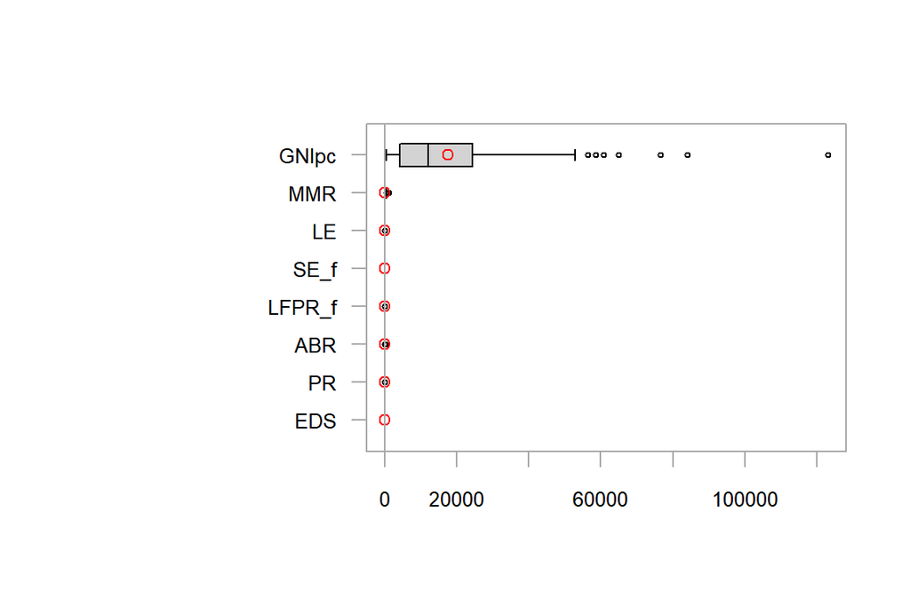

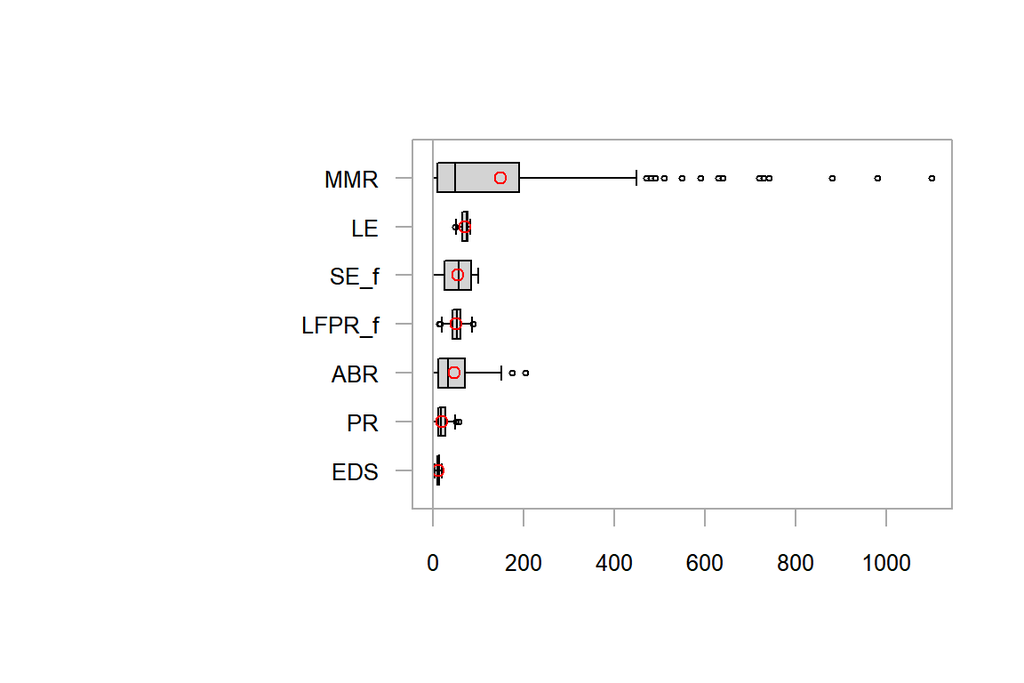

```r
# boxplots of all variables in a wrapper
chart.Boxplot(human, main = NULL, xlab = NULL)

# boxplots of variables excluding 'GNIpc'
humanreduced <- dplyr::select(human, -c(GNIpc))
chart.Boxplot(humanreduced, main = NULL, xlab = NULL)
```

The first boxplot chart above on the left reveals merely that `GNIpc` has by far the widest data range. Also, it’s distribution is heavily skewed to the right and it has quite a few outliers (i.e. value points more than 1.5 times the IQR from the box edges).

When the variables with more compact ranges are plotted without `GNIpc` (plot on the right above), the boxplots can be interpreted e.g. as follows:  
- `MMR` has a relatively wide range and is heavily skewed to the right  
- also `ABR` is heavily right-skewed and has a relatively wide range  
- `LE` is somewhat skewed to the left and `PR` to the right  
- `SE_f` is spread more evenly than the other variables, i.e. has a longer box (IQR)  
- `EDS` and likely `LFPR_f` too, are normally distributed.

#### Correlations

This graph output by `chart.Correlation()` not only illustrates the correlation matrix but also outputs histograms and scatterplots with fitted lines for each variable in a visually informative package. Because of the histograms (on the diagonal) this graph alone might be sufficient to explore distributions as well as correlations. The bivariate scatterplots (on the bottom of the diagonal) are a nice addition and allow for interpretation of any potentially non-linear patterns in the relationships.

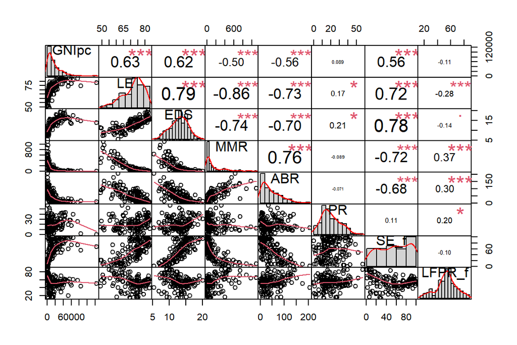

```r
# correlation matrix plotted with histograms
chart.Correlation(human, histogram = TRUE, pch=19)
```

On top of the diagonal, the numbers are Pearson correlation coefficients describing the strength of the relationship between each pair of variables. The stars indicate p-values, i.e. the significance of the relationship. Th strongest, statistically significant correlation is between `LE` and `MMR`. In fact, there’s a group of variables (`LE`, `EDS`, `MMR`, `ABR` and `SE`) that seem quite strongly interrelated having either negative or positive correlations. `GNIpc` has somewhat weaker correlations, most significantly with `LE` and `EDS`. `LFPR_f` has only weak correlations. `PR` on the other hand, does not correlate much at all with the other variables.

### 5.2 PCA with non-standardized data

This dataset with 8 variables is multidimensional making it a challenge to interpret the data. The dimensions can be reduced and the principal components (i.e. linear combinations or mixtures of the initial variables) can be identified using the PCA method. According to DataCamp (Helsinki ODS Course) the preferred `base r` function for PCA is `prcomp` which uses SVD (Singular Value Decomposition) method. It decomposes the data matrix into a product of smaller matrices, which extract the underlying principal components.

First, I’ll perform PCA with non-standardized data.

```r
# perform principal component analysis (with the SVD method)
pca_human <- prcomp(human)

# summary of pca_human
s<- summary(pca_human)

# rounded % of variance captured by each PC
pca_pr <- round(100*s$importance[2,], digits = 1)

# print out % of variance
pca_pr
```

```
## PC1 PC2 PC3 PC4 PC5 PC6 PC7 PC8
## 100   0   0   0   0   0   0   0
```

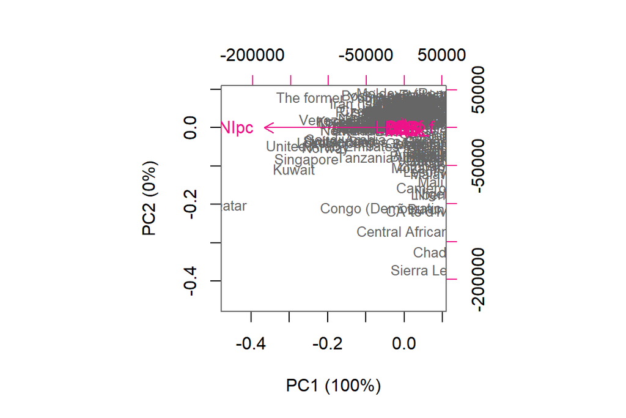

```r
# create object pc_lab to be used as axis labels
pc_lab <- paste0(names(pca_pr), " (", pca_pr, "%)")

# draw a biplot
biplot(pca_human, cex = c(0.8, 1), col = c("grey40", "deeppink2"), xlab = pc_lab[1], ylab = pc_lab[2])
```

### 5.3 PCA with standardized data

Now, PCA is performed with standardized data. And indeed, as expected: the results are quite different from the first attempt with non-standardized data.

```r
# standardize the variables
human_std <- scale(human)

# perform principal component analysis (with the SVD method)
pca_human <- prcomp(human_std)

# summary of pca_human
s<- summary(pca_human)

# rounded % of variance captured by each PC
pca_pr <- round(100*s$importance[2,], digits = 1)

# print out % of variance
pca_pr
```

```
##  PC1  PC2  PC3  PC4  PC5  PC6  PC7  PC8
## 57.0 15.6  9.6  6.5  3.8  3.5  2.5  1.4
```

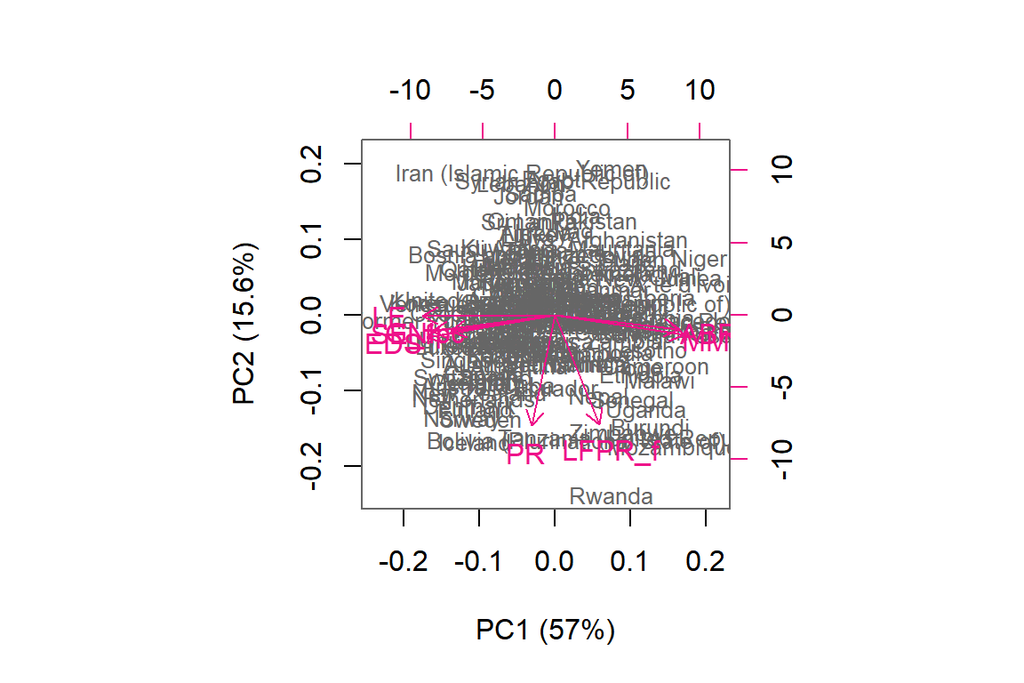

FIGURE 5.3 PCA on dataset with standardized variables measuring gender inequality and human development in 155 countries.

```r
# create object pc_lab to be used as axis labels
pc_lab <- paste0(names(pca_pr), " (", pca_pr, "%)")

# draw a biplot
biplot(pca_human, cex = c(0.8, 1), col = c("grey40", "deeppink2"), xlab = pc_lab[1], ylab = pc_lab[2])
```

The takeaway is clear: the results of PCA depend on the scaling of the variables. This can be avoided by standardization.

When the variables were **not standardized** (figure 5.2), PC1 explained 100% of the variation in the dataset which would be a great result (but highly susceptible) *if* the analysis was performed with standardized variables. Here, the “most contributing” original variable `GNIpc` is actually, and simply, the variables with highest mean in the dataset.

With standardized data, the variable arrows are actually comparable with each other and the PCs. Let’s interpret the loading plot, i.e. the arrows (or vectors) showing the influence of each original variable on the PCs.  
- Group 1 (negative influence on PC1): variables `LE`, `SE_f`, `EDS` and `Gnipc` are grouped close together, meaning that they have positive correlation.  
- Group 2 (positive influence on PC1): Similarly, `ABR` and `MMR` form another group with not much angle between them, again, indicating positive correlation.  
- Groups 1 and 2 have pretty similar (high) scores on PC1, so these variables have about as much influence on PC1 - only to opposite directions, meaning that the groups are negatively correlated. Their contribution to PC2 is minimal.  
- Group 3 (negative influence on PC2): variables `PR` and `LFPR_f` contribute most to PC2. They have some angle between them, so they are only weakly correlated.

### 5.4 My interpretation of the PCs

The dimensions of human development: health, education, and standard of living, are represented in the `human` dataset by life expectancy `LE`, expected years of schooling `EDS` and gross national income per capita `GNIpc`, respectively. Combined with the dimensions driving gender inequality: reproductive health, empowerment and economic status of women, this dataset yields insight on the position of women and the human development costs of gender inequality in the 155 countries included. Reproductive health is represented in this dataset by maternal mortality ratio `MMR`and adolescent birth rates `ABR`, empowerment by female representation in parliament `PR` and proportion with secondary education `SE_f`, and economic status by the labor force participation rate `LFPR_f`.

### 5.5 MCA with ‘tea’ data

Multiple Correspondence Analysis (MCA) can be used to analyze the systematic patterns of variation with categorical data. It has some special features that make it mathematically different from PCA, but they both share a lot of things in common from a data analysis standpoint. The data should be in a dataframe with qualitative variables (factors) in the columns.

```r
# load data
data("tea")
```

The data used here is included in `FactoMineR` package. The dataset comes from a questionnaire about tea consumption. 300 individuals were asked how they drink tea (18 questions), what are their product’s perception (12 questions) and some personal details (4 questions). The questionnaire is described in more detail by Husson, F., Le, S. and Pages, J. (2010). Exploratory Multivariate Analysis by Example Using R, Chapman and Hall.

```r
# print structure of the dataset
str(tea)
```

```
## 'data.frame':    300 obs. of  36 variables:
##  $ breakfast       : Factor w/ 2 levels "breakfast","Not.breakfast": 1 1 2 2 1 2 1 2 1 1 ...
##  $ tea.time        : Factor w/ 2 levels "Not.tea time",..: 1 1 2 1 1 1 2 2 2 1 ...
##  $ evening         : Factor w/ 2 levels "evening","Not.evening": 2 2 1 2 1 2 2 1 2 1 ...
##  $ lunch           : Factor w/ 2 levels "lunch","Not.lunch": 2 2 2 2 2 2 2 2 2 2 ...
##  $ dinner          : Factor w/ 2 levels "dinner","Not.dinner": 2 2 1 1 2 1 2 2 2 2 ...
##  $ always          : Factor w/ 2 levels "always","Not.always": 2 2 2 2 1 2 2 2 2 2 ...
##  $ home            : Factor w/ 2 levels "home","Not.home": 1 1 1 1 1 1 1 1 1 1 ...
##  $ work            : Factor w/ 2 levels "Not.work","work": 1 1 2 1 1 1 1 1 1 1 ...
##  $ tearoom         : Factor w/ 2 levels "Not.tearoom",..: 1 1 1 1 1 1 1 1 1 2 ...
##  $ friends         : Factor w/ 2 levels "friends","Not.friends": 2 2 1 2 2 2 1 2 2 2 ...
##  $ resto           : Factor w/ 2 levels "Not.resto","resto": 1 1 2 1 1 1 1 1 1 1 ...
##  $ pub             : Factor w/ 2 levels "Not.pub","pub": 1 1 1 1 1 1 1 1 1 1 ...
##  $ Tea             : Factor w/ 3 levels "black","Earl Grey",..: 1 1 2 2 2 2 2 1 2 1 ...
##  $ How             : Factor w/ 4 levels "alone","lemon",..: 1 3 1 1 1 1 1 3 3 1 ...
```

[output cut: 22 more lines]

The dataset `tea` is a dataframe with 300 rows of 36 columns. All variables are factors with two or more levels except `age` which gets integer values. There’s also `age_Q` which is basically `age` grouped in 5 categories.

I’ll select only a few columns for my MCA: 4 active variables and 2 supplementary variables.  
`Tea` What kind of tea do you drink?  
`How` How do you take your tea?  
`price` What kind of tea do you buy?  
`how` How do you buy your tea?  
`age_Q` age group (supplementary)  
`sophisticated` Is drinking tea sophisticated? (supplementary)

```r
# column names to keep in the dataset
keep_columns <- c("Tea", "How", "price", "how", "age_Q", "sophisticated")

# select the 'keep_columns' to create a new dataset
tea_time <- dplyr::select(tea, one_of(keep_columns))

# look at the summaries and structure of the data
str(tea_time)
```

```
## 'data.frame':    300 obs. of  6 variables:
##  $ Tea          : Factor w/ 3 levels "black","Earl Grey",..: 1 1 2 2 2 2 2 1 2 1 ...
##  $ How          : Factor w/ 4 levels "alone","lemon",..: 1 3 1 1 1 1 1 3 3 1 ...
##  $ price        : Factor w/ 6 levels "p_branded","p_cheap",..: 4 6 6 6 6 3 6 6 5 5 ...
##  $ how          : Factor w/ 3 levels "tea bag","tea bag+unpackaged",..: 1 1 1 1 1 1 1 1 2 2 ...
##  $ age_Q        : Factor w/ 5 levels "15-24","25-34",..: 3 4 4 1 4 1 3 3 3 3 ...
##  $ sophisticated: Factor w/ 2 levels "Not.sophisticated",..: 1 1 1 2 1 1 1 2 2 1 ...
```

```r
summary(tea_time)
```

```
##         Tea         How                  price                     how
##  black    : 74   alone:195   p_branded      : 95   tea bag           :170
##  Earl Grey:193   lemon: 33   p_cheap        :  7   tea bag+unpackaged: 94
##  green    : 33   milk : 63   p_private label: 21   unpackaged        : 36
##                  other:  9   p_unknown      : 12
##                              p_upscale      : 53
##                              p_variable     :112
##    age_Q              sophisticated
##  15-24:92   Not.sophisticated: 85
##  25-34:69   sophisticated    :215
##  35-44:40
##  45-59:61
##  +60  :38
##
```

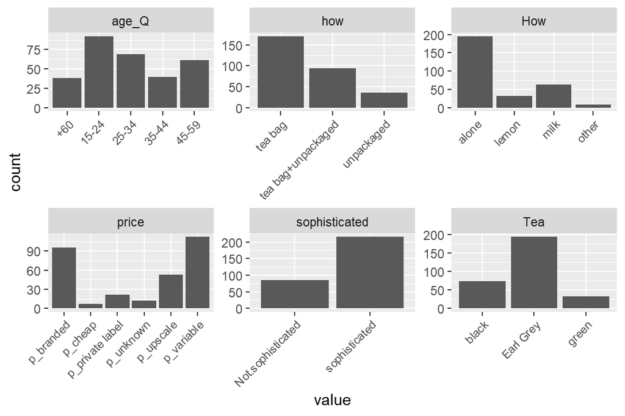

```r
# visualize the dataset
gather(tea_time) %>% ggplot(aes(value)) + facet_wrap("key", scales = "free") + geom_bar() + theme(axis.text.x = element_text(angle = 45, hjust = 1, size = 8))
```

```r
# multiple correspondence analysis
mca <- MCA(tea_time, quali.sup=5:6, graph = FALSE)
mca
```

```
## **Results of the Multiple Correspondence Analysis (MCA)**
## The analysis was performed on 300 individuals, described by 6 variables
## *The results are available in the following objects:
##
##    name                description
## 1  "$eig"              "eigenvalues"
## 2  "$var"              "results for the variables"
## 3  "$var$coord"        "coord. of the categories"
## 4  "$var$cos2"         "cos2 for the categories"
## 5  "$var$contrib"      "contributions of the categories"
## 6  "$var$v.test"       "v-test for the categories"
## 7  "$ind"              "results for the individuals"
## 8  "$ind$coord"        "coord. for the individuals"
## 9  "$ind$cos2"         "cos2 for the individuals"
## 10 "$ind$contrib"      "contributions of the individuals"
## 11 "$quali.sup"        "results for the supplementary categorical variables"
## 12 "$quali.sup$coord"  "coord. for the supplementary categories"
## 13 "$quali.sup$cos2"   "cos2 for the supplementary categories"
## 14 "$quali.sup$v.test" "v-test for the supplementary categories"
## 15 "$call"             "intermediate results"
## 16 "$call$marge.col"   "weights of columns"
## 17 "$call$marge.li"    "weights of rows"
```

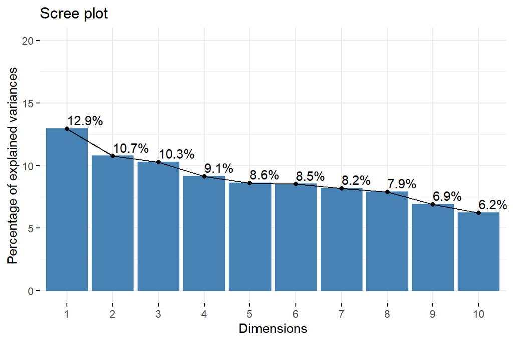

```r
#visualize eigenvalues
fviz_eig(mca, addlabels = TRUE, ylim = c(0, 20))
```

Eigenvalues correspond to the amount of variation explained by each dimension. In my MCA, the first two dimensions explain no more than 23.6% of the variation.

It’s also possible to check how well the dimensions 1 and 2 represent the variable categories (i.e. factors by level).

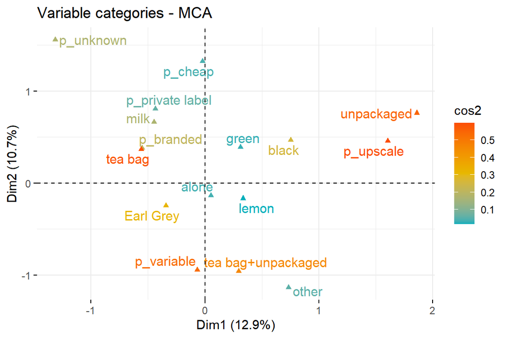

```r
# Color by cos2 values: quality of representation on the factor map
fviz_mca_var(mca, col.var = "cos2",
             gradient.cols = c("#00AFBB", "#E7B800", "#FC4E07"),
             repel = TRUE, # Avoid text overlapping
             ggtheme = theme_minimal(),
             invisible = "quali.sup")
```

The closer to 1 (red color) the cos2 value is, the better the dimensions 1 and 2 represent each category. None of the categories are a perfect match (the highest cos values are 0.6) to either dimension. There are several categories poorly represented (cos2 < 0.1) by these dimension, therefore, the two-dimensional scatterplot should be interpreted with caution.

The scatterplot shows the relationships between variable categories. In the plot below, the active variables are colored red and supplementary variables green.

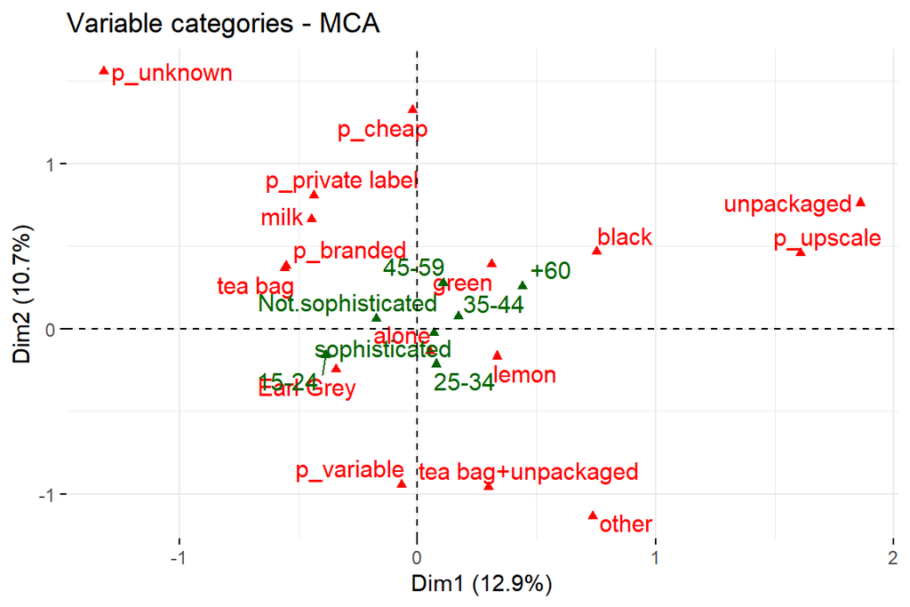

```r
# visualize variable categories
fviz_mca_var(mca,
             repel = TRUE, # to avoid text overlapping
             ggtheme = theme_minimal())
```

Variable categories with a similar profile are grouped together, e.g. “unpackaged” and “p_upscale”. Negatively correlated variable categories are positioned on opposite sides of the plot origin, e.g. . “p_unknown” and “other”. The distance between category points and the origin measures the quality of the variable category, i.e. category points that are away from the origin (e.g. “p_unknown”) are well represented on the factor map.

It’s also interesting to look at the contribution of each variable to dimensions 1 and 2.

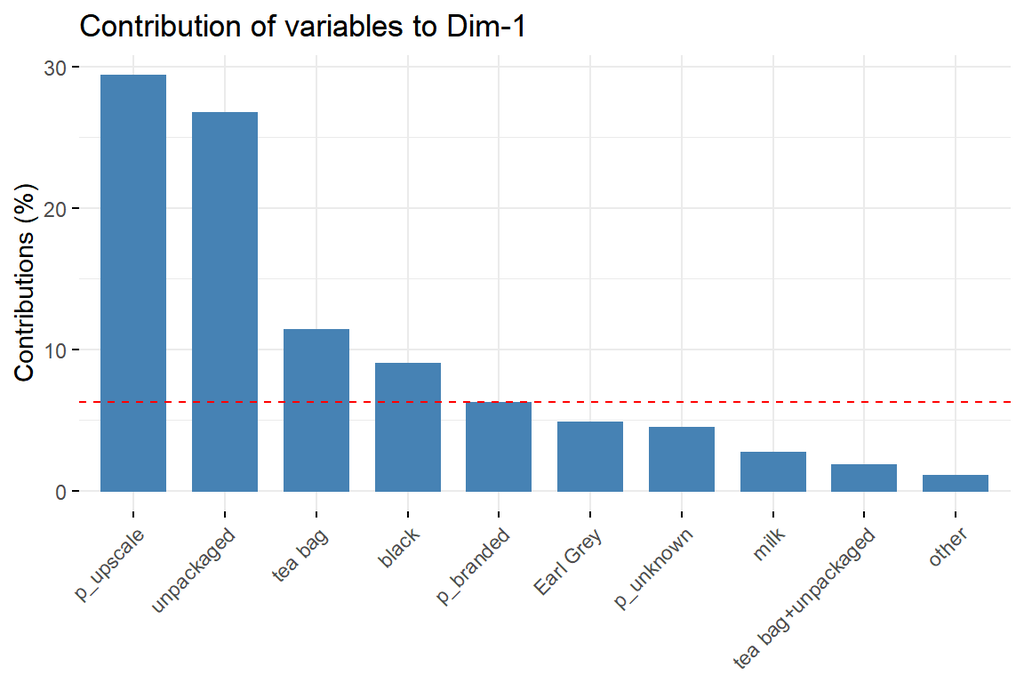

```r
# Contributions to dimension 1
fviz_contrib(mca, choice = "var", axes = 1, top = 10)
```

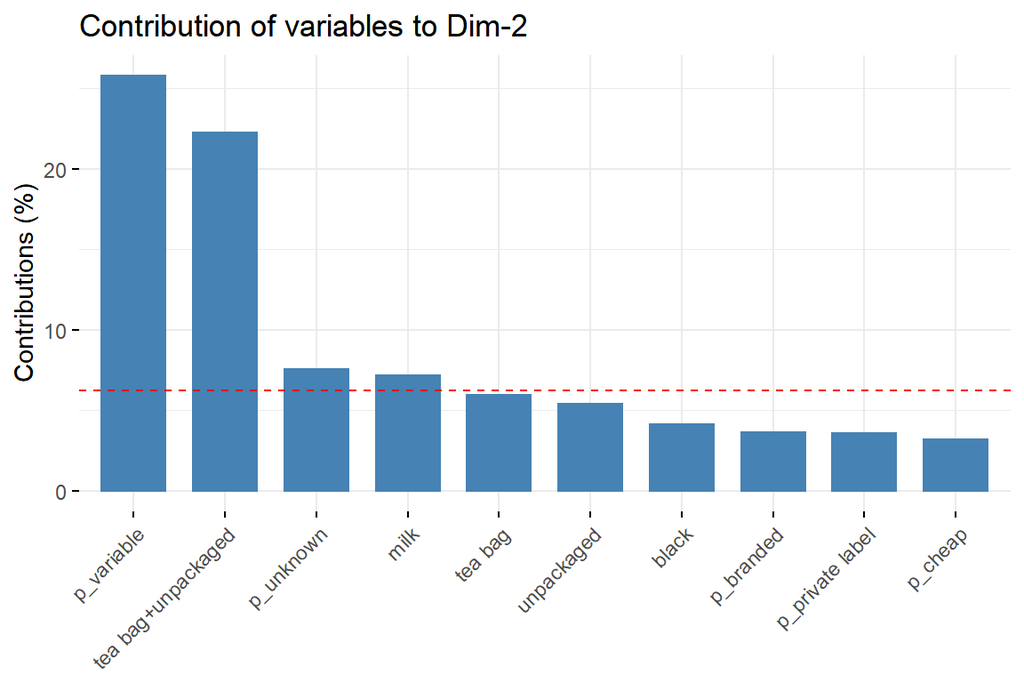

```r
# Contributions to dimension 2
fviz_contrib(mca, choice = "var", axes = 2, top = 10)
```

The variable categories with the larger values, contribute the most to the definition of the dimensions. Categories “p_upscale” and “unpackaged” contribute most to dimension 1, and categories “p_variable” and “tea bag+unpackaged” to dimension 2. These contributions can be visualized on a scatterplot by highlighting the categories with a color gradient.

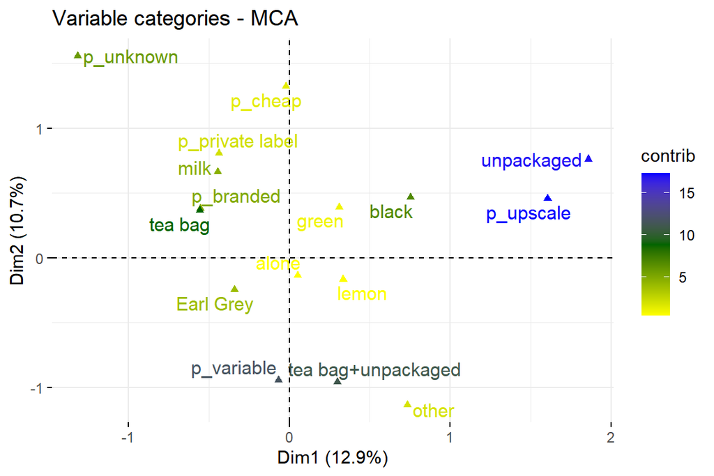

```r
# Contributions of variables to dimensions 1 and 2
fviz_mca_var(mca, col.var = "contrib",
             gradient.cols = c("yellow", "dark green" ,"blue"),
             repel = TRUE, # avoid text overlapping (slow)
             ggtheme = theme_minimal(),
             invisible = "quali.sup"
             )
```

In the plot above, the most important (contributing) categories are highlighted by color blue.

# 6. Analysis of longitudinal data

> The Analysis exercise focuses on exploring your data and performing and interpreting simple straightforward methods (based on summary measures of data) and more advanced methods (called linear mixed effects models). For completing the Analysis exercises, include all the codes, your interpretations and explanations in the R Markdown file chapter6.Rmd.

```
## [1] "Fri Dec 04 21:58:57 2020"
```

```r
# access libraries
library(tidyr); library(dplyr); library(ggplot2); library(lme4)
```

### 6.1 The BPRSL and RATSL datasets

```r
# read datasets in both wide and long form into memory
# wide form
BPRS <- read.csv(file = 'data/BPRS.csv')
RATS <- read.csv(file = 'data/RATS.csv')
# long form
BPRSL <- read.csv(file = 'data/BPRSL.csv')
RATSL <- read.csv(file = 'data/RATSL.csv')
```

**BPRS** data was retrieved from https://raw.githubusercontent.com/KimmoVehkalahti/MABS/master/Examples/data/BPRS.txt. According to MABS4IODS the data originates from Davis, C. S. (2002). Statistical Methods for the Analysis of Repeated Measurements. Springer, New York. 40 male subjects were randomly assigned to one of two treatment groups and each subject was rated on the brief psychiatric rating scale (BPRS) measured before treatment began (week 0) and then at weekly intervals for eight weeks. The BPRS assesses the level of 18 symptom constructs such as hostility, suspiciousness, hallucinations and grandiosity; each of these is rated from one (not present) to seven (extremely severe). The scale is used to evaluate patients suspected of having schizophrenia.

**RATS** data was retrieved from https://raw.githubusercontent.com/KimmoVehkalahti/MABS/master/Examples/data/rats.txt. According to MABS4IODS the data is from a nutrition study conducted in three groups of rats by Crowder and Hand (1990). Crowder, M. J. and Hand, D. J. (1990). Analysis of Repeated Measurements. Chapman and Hall, London. The three groups were put on different diets, and each animal’s body weight (grams) was recorded repeatedly (approximately weekly, except in week seven when two recordings were taken) over a 9-week period.

```r
# convert categorical variables to factors in both dfs (long form)
BPRSL$treatment <- factor(BPRSL$treatment)
BPRSL$subject <- factor(BPRSL$subject)
RATSL$ID <- factor(RATSL$ID)
RATSL$Group <- factor(RATSL$Group)
```

```r
# print df BPRS (wide form) structure and summary
str(BPRS)
```

```
## 'data.frame':    40 obs. of  11 variables:
##  $ treatment: int  1 1 1 1 1 1 1 1 1 1 ...
##  $ subject  : int  1 2 3 4 5 6 7 8 9 10 ...
##  $ week0    : int  42 58 54 55 72 48 71 30 41 57 ...
##  $ week1    : int  36 68 55 77 75 43 61 36 43 51 ...
##  $ week2    : int  36 61 41 49 72 41 47 38 39 51 ...
##  $ week3    : int  43 55 38 54 65 38 30 38 35 55 ...
##  $ week4    : int  41 43 43 56 50 36 27 31 28 53 ...
##  $ week5    : int  40 34 28 50 39 29 40 26 22 43 ...
##  $ week6    : int  38 28 29 47 32 33 30 26 20 43 ...
##  $ week7    : int  47 28 25 42 38 27 31 25 23 39 ...
##  $ week8    : int  51 28 24 46 32 25 31 24 21 32 ...
```

```r
summary(BPRS)
```

```
##    treatment      subject          week0           week1           week2
##  Min.   :1.0   Min.   : 1.00   Min.   :24.00   Min.   :23.00   Min.   :26.0
##  1st Qu.:1.0   1st Qu.: 5.75   1st Qu.:38.00   1st Qu.:35.00   1st Qu.:32.0
##  Median :1.5   Median :10.50   Median :46.00   Median :41.00   Median :38.0
##  Mean   :1.5   Mean   :10.50   Mean   :48.00   Mean   :46.33   Mean   :41.7
##  3rd Qu.:2.0   3rd Qu.:15.25   3rd Qu.:58.25   3rd Qu.:54.25   3rd Qu.:49.0
##  Max.   :2.0   Max.   :20.00   Max.   :78.00   Max.   :95.00   Max.   :75.0
##      week3           week4           week5           week6           week7
##  Min.   :24.00   Min.   :20.00   Min.   :20.00   Min.   :19.00   Min.   :18.0
##  1st Qu.:29.75   1st Qu.:28.00   1st Qu.:26.00   1st Qu.:22.75   1st Qu.:23.0
##  Median :36.50   Median :34.50   Median :30.50   Median :28.50   Median :30.0
##  Mean   :39.15   Mean   :36.35   Mean   :32.55   Mean   :31.23   Mean   :32.2
##  3rd Qu.:44.50   3rd Qu.:43.00   3rd Qu.:38.00   3rd Qu.:37.00   3rd Qu.:38.0
##  Max.   :76.00   Max.   :66.00   Max.   :64.00   Max.   :64.00   Max.   :62.0
##      week8
##  Min.   :20.00
##  1st Qu.:22.75
##  Median :28.00
##  Mean   :31.43
##  3rd Qu.:35.25
##  Max.   :75.00
```

```r
# print df BPRSL (long form) structure and summary
str(BPRSL)
```

```
## 'data.frame':    360 obs. of  5 variables:
##  $ treatment: Factor w/ 2 levels "1","2": 1 1 1 1 1 1 1 1 1 1 ...
##  $ subject  : Factor w/ 20 levels "1","2","3","4",..: 1 2 3 4 5 6 7 8 9 10 ...
##  $ weeks    : chr  "week0" "week0" "week0" "week0" ...
##  $ bprs     : int  42 58 54 55 72 48 71 30 41 57 ...
##  $ week     : int  0 0 0 0 0 0 0 0 0 0 ...
```

```r
summary(BPRSL)
```

```
##  treatment    subject       weeks                bprs            week
##  1:180     1      : 18   Length:360         Min.   :18.00   Min.   :0
##  2:180     2      : 18   Class :character   1st Qu.:27.00   1st Qu.:2
##            3      : 18   Mode  :character   Median :35.00   Median :4
##            4      : 18                      Mean   :37.66   Mean   :4
##            5      : 18                      3rd Qu.:43.00   3rd Qu.:6
##            6      : 18                      Max.   :95.00   Max.   :8
##            (Other):252
```

```r
tail(BPRSL)
```

```
##     treatment subject weeks bprs week
## 355         2      15 week8   37    8
## 356         2      16 week8   22    8
## 357         2      17 week8   43    8
## 358         2      18 week8   30    8
## 359         2      19 week8   21    8
## 360         2      20 week8   23    8
```

```r
# print df RATS (wide form) structure and summary
str(RATS)
```

```
## 'data.frame':    16 obs. of  13 variables:
##  $ ID   : int  1 2 3 4 5 6 7 8 9 10 ...
##  $ Group: int  1 1 1 1 1 1 1 1 2 2 ...
##  $ WD1  : int  240 225 245 260 255 260 275 245 410 405 ...
##  $ WD8  : int  250 230 250 255 260 265 275 255 415 420 ...
##  $ WD15 : int  255 230 250 255 255 270 260 260 425 430 ...
##  $ WD22 : int  260 232 255 265 270 275 270 268 428 440 ...
##  $ WD29 : int  262 240 262 265 270 275 273 270 438 448 ...
##  $ WD36 : int  258 240 265 268 273 277 274 265 443 460 ...
##  $ WD43 : int  266 243 267 270 274 278 276 265 442 458 ...
##  $ WD44 : int  266 244 267 272 273 278 271 267 446 464 ...
##  $ WD50 : int  265 238 264 274 276 284 282 273 456 475 ...
##  $ WD57 : int  272 247 268 273 278 279 281 274 468 484 ...
##  $ WD64 : int  278 245 269 275 280 281 284 278 478 496 ...
```

```r
summary(RATS)
```

```
##        ID            Group           WD1             WD8             WD15
##  Min.   : 1.00   Min.   :1.00   Min.   :225.0   Min.   :230.0   Min.   :230.0
##  1st Qu.: 4.75   1st Qu.:1.00   1st Qu.:252.5   1st Qu.:255.0   1st Qu.:255.0
##  Median : 8.50   Median :1.50   Median :340.0   Median :345.0   Median :347.5
##  Mean   : 8.50   Mean   :1.75   Mean   :365.9   Mean   :369.1   Mean   :372.5
##  3rd Qu.:12.25   3rd Qu.:2.25   3rd Qu.:480.0   3rd Qu.:476.2   3rd Qu.:486.2
##  Max.   :16.00   Max.   :3.00   Max.   :555.0   Max.   :560.0   Max.   :565.0
##       WD22            WD29            WD36            WD43
##  Min.   :232.0   Min.   :240.0   Min.   :240.0   Min.   :243.0
##  1st Qu.:267.2   1st Qu.:268.8   1st Qu.:267.2   1st Qu.:269.2
##  Median :351.5   Median :356.5   Median :360.0   Median :360.0
##  Mean   :379.2   Mean   :383.9   Mean   :387.0   Mean   :386.0
##  3rd Qu.:492.5   3rd Qu.:497.8   3rd Qu.:504.2   3rd Qu.:501.0
##  Max.   :580.0   Max.   :590.0   Max.   :597.0   Max.   :595.0
##       WD44            WD50            WD57            WD64
##  Min.   :244.0   Min.   :238.0   Min.   :247.0   Min.   :245.0
##  1st Qu.:270.0   1st Qu.:273.8   1st Qu.:273.8   1st Qu.:278.0
##  Median :362.0   Median :370.0   Median :373.5   Median :378.0
##  Mean   :388.3   Mean   :394.6   Mean   :398.6   Mean   :404.1
##  3rd Qu.:510.5   3rd Qu.:516.0   3rd Qu.:524.5   3rd Qu.:530.8
##  Max.   :595.0   Max.   :612.0   Max.   :618.0   Max.   :628.0
```

```r
# print df RATSL (long form) structure and summary
str(RATSL)
```

```
## 'data.frame':    176 obs. of  5 variables:
##  $ ID    : Factor w/ 16 levels "1","2","3","4",..: 1 2 3 4 5 6 7 8 9 10 ...
##  $ Group : Factor w/ 3 levels "1","2","3": 1 1 1 1 1 1 1 1 2 2 ...
##  $ WDs   : chr  "WD1" "WD1" "WD1" "WD1" ...
##  $ weight: int  240 225 245 260 255 260 275 245 410 405 ...
##  $ Time  : int  1 1 1 1 1 1 1 1 1 1 ...
```

```r
summary(RATSL)
```

```
##        ID      Group      WDs                weight           Time
##  1      : 11   1:88   Length:176         Min.   :225.0   Min.   : 1.00
##  2      : 11   2:44   Class :character   1st Qu.:267.0   1st Qu.:15.00
##  3      : 11   3:44   Mode  :character   Median :344.5   Median :36.00
##  4      : 11                             Mean   :384.5   Mean   :33.55
##  5      : 11                             3rd Qu.:511.2   3rd Qu.:50.00
##  6      : 11                             Max.   :628.0   Max.   :64.00
##  (Other):110
```

### 6.2 Analysis of Longitudinal Data I: Graphical Displays and Summary Measure Approach (MABS8)

> Implement the analyses of Chapter 8 of MABS using the RATS data. (0-7 points: 0-4 points for graphs or analysis results + 0-3 points for their interpretations)

#### Individuals on the plot

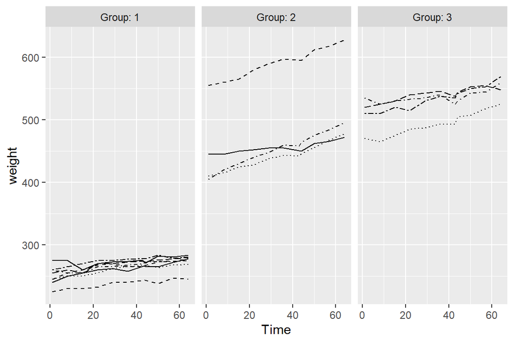

```r
# Draw the plot
ggplot(RATSL, aes(x = Time, y = weight, linetype = ID)) +
  geom_line() +
  scale_linetype_manual(values = rep(1:10, times=4)) +
  facet_grid(. ~ Group, labeller = label_both) +
  theme(legend.position = "none") +
  scale_y_continuous(limits = c(min(RATSL$weight), max(RATSL$weight)))
```

#### Individuals plotted with standardized data

```r
# Standardize the variable weight
RATSL <- RATSL %>%
  group_by(Time) %>%
  mutate(stdweight = (weight - mean(weight))/sd(weight) ) %>%
  ungroup()

# Glimpse at the data
glimpse(RATSL)
```

```
## Rows: 176
## Columns: 6
## $ ID        <fct> 1, 2, 3, 4, 5, 6, 7, 8, 9, 10, 11, 12, 13, 14, 15, 16, 1,...
## $ Group     <fct> 1, 1, 1, 1, 1, 1, 1, 1, 2, 2, 2, 2, 3, 3, 3, 3, 1, 1, 1, ...
## $ WDs       <chr> "WD1", "WD1", "WD1", "WD1", "WD1", "WD1", "WD1", "WD1", "...
## $ weight    <int> 240, 225, 245, 260, 255, 260, 275, 245, 410, 405, 445, 55...
## $ Time      <int> 1, 1, 1, 1, 1, 1, 1, 1, 1, 1, 1, 1, 1, 1, 1, 1, 8, 8, 8, ...
## $ stdweight <dbl> -1.0011429, -1.1203857, -0.9613953, -0.8421525, -0.881900...
```

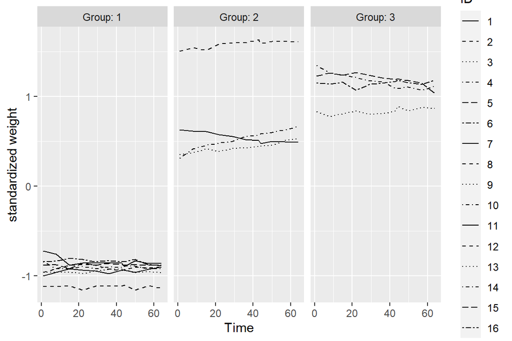

```r
# Plot again with the standardized weight
ggplot(RATSL, aes(x = Time, y = stdweight, linetype = ID)) +
  geom_line() +
  scale_linetype_manual(values = rep(1:10, times=4)) +
  facet_grid(. ~ Group, labeller = label_both) +
  scale_y_continuous(name = "standardized weight")
```

#### Mean ‘weight’ profiles

```r
# Number of days (Time), baseline (day 1) included
n <- RATSL$Time %>% unique() %>% length()

# Summary data with mean and standard error of weight by Group and Time
RATSS <- RATSL %>%
  group_by(Group, Time) %>%
  summarise( mean = mean(weight), se = sd(weight)/sqrt(n) ) %>%
  ungroup()
# Glimpse the data
glimpse(RATSS)
```

```
## Rows: 33
## Columns: 4
## $ Group <fct> 1, 1, 1, 1, 1, 1, 1, 1, 1, 1, 1, 2, 2, 2, 2, 2, 2, 2, 2, 2, 2...
## $ Time  <int> 1, 8, 15, 22, 29, 36, 43, 44, 50, 57, 64, 1, 8, 15, 22, 29, 3...
## $ mean  <dbl> 250.625, 255.000, 254.375, 261.875, 264.625, 265.000, 267.375...
## $ se    <dbl> 4.589478, 3.947710, 3.460116, 4.100800, 3.333956, 3.552939, 3...
```

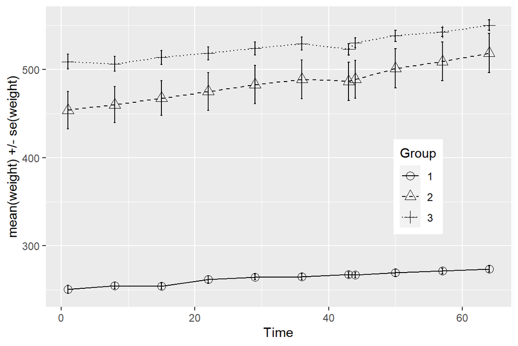

```r
# Plot the mean profiles
ggplot(RATSS, aes(x = Time, y = mean, linetype = Group, shape = Group)) +
  geom_line() +
  scale_linetype_manual(values = c(1,2,3)) +
  geom_point(size=3) +
  scale_shape_manual(values = c(1,2,3)) +
  geom_errorbar(aes(ymin = mean - se, ymax = mean + se, linetype="1"), width=0.3) +
  theme(legend.position = c(0.8,0.4)) +
  scale_y_continuous(name = "mean(weight) +/- se(weight)")
```

With large numbers of observations, graphical displays of individual response profiles are of little use and investigators then commonly produce graphs showing average (mean) profiles for each treatment group along with some indication of the variation of the observations at each time point, in this case the standard error of mean. There is no overlap in the mean profiles of the three diet groups suggesting these groups are quite different for each other in respect to the mean weights.

#### Dealing with outliers

```r
# Create a summary data by Group and ID with mean as the summary variable (ignoring baseline day 1).
RATSL64S <- RATSL %>%
  filter(Time > 1) %>%
  group_by(Group, ID) %>%
  summarise( mean=mean(weight) ) %>%
  ungroup()
# Glimpse the data
glimpse(RATSL64S)
```

```
## Rows: 16
## Columns: 3
## $ Group <fct> 1, 1, 1, 1, 1, 1, 1, 1, 2, 2, 2, 2, 3, 3, 3, 3
## $ ID    <fct> 1, 2, 3, 4, 5, 6, 7, 8, 9, 10, 11, 12, 13, 14, 15, 16
## $ mean  <dbl> 263.2, 238.9, 261.7, 267.2, 270.9, 276.2, 274.6, 267.5, 443.9...
```

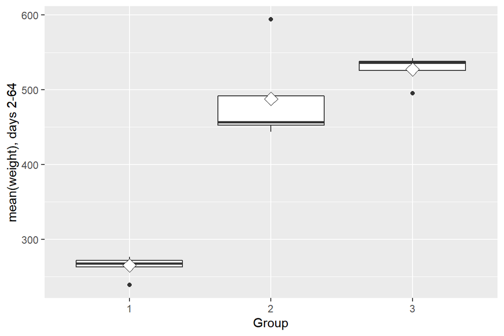

```r
# Draw a boxplot of the mean versus Group
ggplot(RATSL64S, aes(x = Group, y = mean)) +
  geom_boxplot() +
  stat_summary(fun.y = "mean", geom = "point", shape=23, size=4, fill = "white") +
  scale_y_continuous(name = "mean(weight), days 2-64")
```

While all three Groups in the above plot have one outlier each, the mean weight of days 2-64 is more variable in Group 2. Because of the outliers in Groups 2 and 3, the distributions (mean of days 2-64) are overlapping. In the plot below, the outlier in Group 2 was filtered out, and now there no longer is any overlap between Groups 2 and 3. Because Group 2 has only 4 rats, I’m hesitating about removing the outlier, anyway.

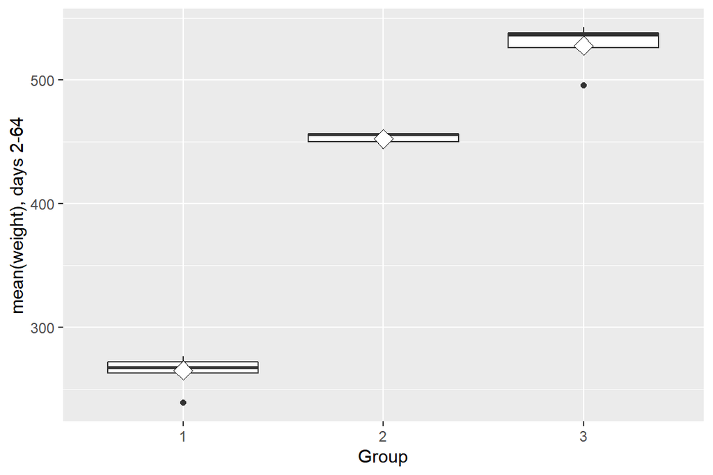

```r
# Create a new data by filtering the outlier and adjust the ggplot code the draw the plot again with the new data
RATSL64S1 <- RATSL64S %>%
  filter(mean < 580)
ggplot(RATSL64S1, aes(x = Group, y = mean)) +
  geom_boxplot() +
  stat_summary(fun.y = "mean", geom = "point", shape=23, size=4, fill = "white") +
  scale_y_continuous(name = "mean(weight), days 2-64")
```

#### Linear model with tests

Because I’m not sure about removing the outlier (see above), I’ll perform anova on both summary data with and without the outlier. I’ll use anova instead on a t-test, because there are more than two Groups to compare.

```r
# Perform one-way anova (instead of a t-test) with the outlier
aov <- aov(mean ~ Group, data = RATSL64S)
summary(aov)
```

```
##             Df Sum Sq Mean Sq F value   Pr(>F)
## Group        2 238620  119310   88.53 2.68e-08 ***
## Residuals   13  17521    1348
## ---
## Signif. codes:  0 '***' 0.001 '**' 0.01 '*' 0.05 '.' 0.1 ' ' 1
```

```r
TukeyHSD(aov)
```

```
##   Tukey multiple comparisons of means
##     95% family-wise confidence level
##
## Fit: aov(formula = mean ~ Group, data = RATSL64S)
##
## $Group
##        diff       lwr      upr     p adj
## 2-1 222.775 163.41452 282.1355 0.0000006
## 3-1 262.475 203.11452 321.8355 0.0000001
## 3-2  39.700 -28.84358 108.2436 0.3099506
```

```r
# Perform one-way anova without the outlier
aov <- aov(mean ~ Group, data = RATSL64S1)
summary(aov)
```

```
##             Df Sum Sq Mean Sq F value   Pr(>F)
## Group        2 207659  103830   501.8 2.72e-12 ***
## Residuals   12   2483     207
## ---
## Signif. codes:  0 '***' 0.001 '**' 0.01 '*' 0.05 '.' 0.1 ' ' 1
```

```r
TukeyHSD(aov)
```

```
##   Tukey multiple comparisons of means
##     95% family-wise confidence level
##
## Fit: aov(formula = mean ~ Group, data = RATSL64S1)
##
## $Group
##        diff       lwr      upr    p adj
## 2-1 187.375 161.39457 213.3554 0.00e+00
## 3-1 262.475 238.97481 285.9752 0.00e+00
## 3-2  75.100  45.79012 104.4099 4.98e-05
```

I can’t figure out how to add the baseline to the summary data without the outlier because RATS$Wd1 has 16 values and the summary data without outlier RATSL64S1 can only take 15 values as baseline. Maybe I should figure out the ID of the outlier and filter it out of the wide form dataframe first.

(Note: I think that there’s an error in the DataComp solution as it uses BPRSL8S, although instructions are to use BPRSL8S1).

```r
# Add the baseline from the original data as a new variable to the summary data without the outlier
RATSL64S2 <- RATSL64S1 %>%
  mutate(baseline = RATS$WD1)

# Fit the linear model with the mean as the response
fit <- lm(mean ~ baseline + Group, data = RATSL64S2)

# Compute the analysis of variance table for the fitted model with anova()
anova(fit)
```

[output not shown]

When the outlier is not removed (see analysis below), the baseline is strongly related to the weights measured after the diet was started, but there’s just not enough evidence for a difference between the Groups. So unless I figure out how to deal with that outlier, the conclusion based on this summary measure approach is that there was no statistically significant difference between the three groups of rats.

```r
# Add the baseline from the original data as a new variable to the summary data
RATSL64S2 <- RATSL64S %>%
  mutate(baseline = RATS$WD1)

# Fit the linear model with the mean as the response
fit <- lm(mean ~ baseline + Group, data = RATSL64S2)

# Compute the analysis of variance table for the fitted model with anova()
anova(fit)
```

```
## Analysis of Variance Table
##
## Response: mean
##           Df Sum Sq Mean Sq   F value   Pr(>F)
## baseline   1 253625  253625 1859.8201 1.57e-14 ***
## Group      2    879     439    3.2219  0.07586 .
## Residuals 12   1636     136
## ---
## Signif. codes:  0 '***' 0.001 '**' 0.01 '*' 0.05 '.' 0.1 ' ' 1
```

### 6.3 Analysis of Longitudinal Data II: Linear Mixed Effects Models for Normal Response Variables

> Implement the analyses of Chapter 9 of MABS using the BPRS data. (0-8 points: 0-4 points for graphs or analysis results + 0-4 points for their interpretations)

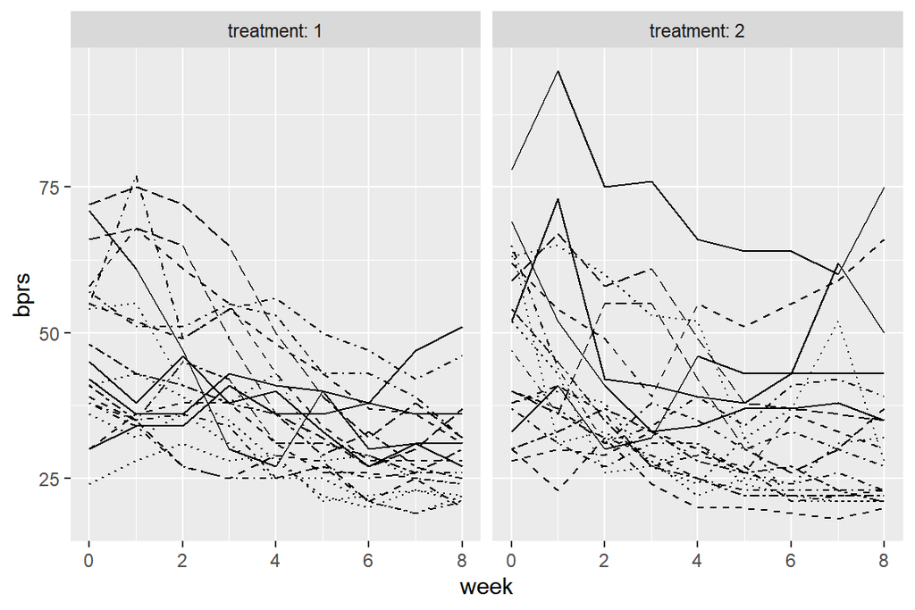

```r
# Draw the plot
ggplot(BPRSL, aes(x = week, y = bprs, linetype = subject)) +
  geom_line() +
  scale_linetype_manual(values = rep(1:10, times=4)) +
  facet_grid(. ~ treatment, labeller = label_both) +
  theme(legend.position = "none") +
  scale_y_continuous(limits = c(min(BPRSL$bprs), max(BPRSL$bprs)))
```

```r
# create a regression model BPRS_reg
BPRS_reg <- lm(bprs ~ week + treatment, data = BPRSL)

# print out a summary of the model
summary(BPRS_reg)
```

```
##
## Call:
## lm(formula = bprs ~ week + treatment, data = BPRSL)
##
## Residuals:
##     Min      1Q  Median      3Q     Max
## -22.454  -8.965  -3.196   7.002  50.244
##
## Coefficients:
##             Estimate Std. Error t value Pr(>|t|)
## (Intercept)  46.4539     1.3670  33.982   <2e-16 ***
## week         -2.2704     0.2524  -8.995   <2e-16 ***
## treatment2    0.5722     1.3034   0.439    0.661
## ---
## Signif. codes:  0 '***' 0.001 '**' 0.01 '*' 0.05 '.' 0.1 ' ' 1
##
## Residual standard error: 12.37 on 357 degrees of freedom
## Multiple R-squared:  0.1851, Adjusted R-squared:  0.1806
## F-statistic: 40.55 on 2 and 357 DF,  p-value: < 2.2e-16
```

```r
# Create a random intercept model
BPRS_ref <- lmer(bprs ~ week + treatment + (1 | subject), data = BPRSL, REML = FALSE)

# Print the summary of the model
summary(BPRS_ref)
```

```
## Linear mixed model fit by maximum likelihood  ['lmerMod']
## Formula: bprs ~ week + treatment + (1 | subject)
##    Data: BPRSL
##
##      AIC      BIC   logLik deviance df.resid
##   2748.7   2768.1  -1369.4   2738.7      355
##
## Scaled residuals:
##     Min      1Q  Median      3Q     Max
## -3.0481 -0.6749 -0.1361  0.4813  3.4855
##
## Random effects:
##  Groups   Name        Variance Std.Dev.
##  subject  (Intercept)  47.41    6.885
##  Residual             104.21   10.208
## Number of obs: 360, groups:  subject, 20
##
## Fixed effects:
##             Estimate Std. Error t value
## (Intercept)  46.4539     1.9090  24.334
## week         -2.2704     0.2084 -10.896
## treatment2    0.5722     1.0761   0.532
##
## Correlation of Fixed Effects:
##            (Intr) week
## week       -0.437
## treatment2 -0.282  0.000
```

```r
# create a random intercept and random slope model
BPRS_ref1 <- lmer(bprs ~ week + treatment + (week | subject), data = BPRSL, REML = FALSE)

# print a summary of the model
summary(BPRS_ref1)
```

```
## Linear mixed model fit by maximum likelihood  ['lmerMod']
## Formula: bprs ~ week + treatment + (week | subject)
##    Data: BPRSL
##
##      AIC      BIC   logLik deviance df.resid
##   2745.4   2772.6  -1365.7   2731.4      353
##
## Scaled residuals:
##     Min      1Q  Median      3Q     Max
## -2.8919 -0.6194 -0.0691  0.5531  3.7976
##
## Random effects:
##  Groups   Name        Variance Std.Dev. Corr
##  subject  (Intercept) 64.8222  8.0512
##           week         0.9609  0.9802   -0.51
##  Residual             97.4305  9.8707
## Number of obs: 360, groups:  subject, 20
##
## Fixed effects:
##             Estimate Std. Error t value
## (Intercept)  46.4539     2.1052  22.066
## week         -2.2704     0.2977  -7.626
## treatment2    0.5722     1.0405   0.550
##
## Correlation of Fixed Effects:
##            (Intr) week
## week       -0.582
## treatment2 -0.247  0.000
```

```r
# perform an ANOVA test on the two models
anova(BPRS_ref1, BPRS_ref)
```

```
## Data: BPRSL
## Models:
## BPRS_ref: bprs ~ week + treatment + (1 | subject)
## BPRS_ref1: bprs ~ week + treatment + (week | subject)
##           npar    AIC    BIC  logLik deviance  Chisq Df Pr(>Chisq)
## BPRS_ref     5 2748.7 2768.1 -1369.4   2738.7
## BPRS_ref1    7 2745.4 2772.6 -1365.7   2731.4 7.2721  2    0.02636 *
## ---
## Signif. codes:  0 '***' 0.001 '**' 0.01 '*' 0.05 '.' 0.1 ' ' 1
```

```r
# create a random intercept and random slope model
BPRS_ref2 <- lmer(bprs ~ week * treatment + (week | subject), data = BPRSL, REML = FALSE)

# print a summary of the model
summary(BPRS_ref2)
```

```
## Linear mixed model fit by maximum likelihood  ['lmerMod']
## Formula: bprs ~ week * treatment + (week | subject)
##    Data: BPRSL
##
##      AIC      BIC   logLik deviance df.resid
##   2744.3   2775.4  -1364.1   2728.3      352
##
## Scaled residuals:
##     Min      1Q  Median      3Q     Max
## -3.0512 -0.6271 -0.0768  0.5288  3.9260
##
## Random effects:
##  Groups   Name        Variance Std.Dev. Corr
##  subject  (Intercept) 64.9964  8.0620
##           week         0.9687  0.9842   -0.51
##  Residual             96.4707  9.8220
## Number of obs: 360, groups:  subject, 20
##
## Fixed effects:
##                 Estimate Std. Error t value
## (Intercept)      47.8856     2.2521  21.262
## week             -2.6283     0.3589  -7.323
## treatment2       -2.2911     1.9090  -1.200
## week:treatment2   0.7158     0.4010   1.785
##
## Correlation of Fixed Effects:
##             (Intr) week   trtmn2
## week        -0.650
## treatment2  -0.424  0.469
## wek:trtmnt2  0.356 -0.559 -0.840
```

```r
# perform an ANOVA test on the two models
anova(BPRS_ref2, BPRS_ref1)
```

```
## Data: BPRSL
## Models:
## BPRS_ref1: bprs ~ week + treatment + (week | subject)
## BPRS_ref2: bprs ~ week * treatment + (week | subject)
##           npar    AIC    BIC  logLik deviance  Chisq Df Pr(>Chisq)
## BPRS_ref1    7 2745.4 2772.6 -1365.7   2731.4
## BPRS_ref2    8 2744.3 2775.4 -1364.1   2728.3 3.1712  1    0.07495 .
## ---
## Signif. codes:  0 '***' 0.001 '**' 0.01 '*' 0.05 '.' 0.1 ' ' 1
```

```r
# draw the plot of BPRSL
ggplot(BPRSL, aes(x = week, y = bprs, group = subject)) +
  geom_line(aes(linetype = treatment)) +
  scale_x_continuous(name = "week", breaks = seq(0, 60, 20)) +
  scale_y_continuous(name = "observed bprs") +
  theme(legend.position = "top")

# Create a vector of the fitted values
Fitted <- fitted(BPRS_ref2)

# Create a new column fitted to BPRSL
BPRSL <- BPRSL %>%
  mutate(Fitted)

# draw the plot of BPRSL
ggplot(BPRSL, aes(x = week, y = Fitted, group = subject)) +
  geom_line(aes(linetype = treatment)) +
  scale_x_continuous(name = "week", breaks = seq(0, 60, 20)) +
  scale_y_continuous(name = "Fitted bprs") +
  theme(legend.position = "top")
```

[output not shown]

(more chapters to be added similarly as we proceed with the course!)